# IE582 Homework 2

Anıl Turgut - 2022702072

2023-12-11

## Introduction

In this assignment, we will examine the performance and suitability of the different Machine Learning algorithms we learned in 582 lessons on 5 different types of datasets. I have generally used the lecture notes and example scripts in the moodle, but I have took some help while implementing knn.reg() (kNN regression), kknn() (for manhattan distance).

We will examine 5 different datasets in accordance with the formats specified in Assignment separately in this report. It will be a long report since all 5 cases are analyzed, preprocessed, modeled and tested with 4 main learning algorithms (with cross validation to tune parameters). Cases are listed below (ordered):

-Diabetes Case -Student Success Case -Malware Type Detection Case -Glioma Cancer Detection Case -Predicting Large-scale Wave Energy Case

There was some rules about dataset in the assignment page in the moodle in terms of dataset requirements. Below shows which dataset satisfies which rule/rules:

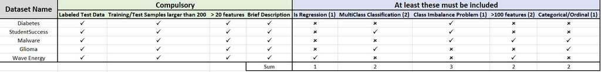

Dataset Rules

### Initialization : Loading required libraries.

At first, We loaded the data to the R Environment to complete the parts of the question. Also, loaded some libraries providing the visualizations to interpret the data and machine learning algorithms to fit the model etc..

```r
library(data.table)
library(tidyverse)
library(ggplot2)
library(rpart.plot)
library(skimr)
library(GGally)
library(caret) # for machine learning and predictive modeling
library(class) # for kNN
library(kknn) # for kNN with Manhattan Distance
library(rpart) # for rpart
library(gbm) # for Boosted Decision Trees
library(randomForest) # for random forests
library(reshape2) # for graphs
library(FNN)
library(class)
require(rattle)
library(pROC)
library(pdp)
library(MLmetrics)
library(magick)
```

Note that the `path` is set to the folder including the 5 different datasets in my computer. Please change it to run the commands properly.

```r
data_path <- "C:/Users/anil.turgut/Desktop/582HW2/Dataset/"
```

## Diabetes Case

### Part 1.0 : Explaining the Diabetes Case and loading the data.

Diabetes is a serious chronic disease in which individuals lose the ability to effectively regulate levels of glucose in the blood, and can lead to reduced quality of life and life expectancy. Early diagnosis can lead to lifestyle changes and more effective treatment, making predictive models for diabetes risk important tools for public and public health officials.

In this part of the assignment, we mainly try to diagnose the diabetes disease. Let’s start by loading the data to the environment.

```r
diabetes_data_path <- paste0(data_path,"Diabetes/diabetes.csv")

diabetes_data <- read.csv(diabetes_data_path)

head(diabetes_data)
```

```
##   Diabetes_binary HighBP HighChol CholCheck BMI Smoker Stroke
## 1               0      1        1         1  40      1      0
## 2               0      0        0         0  25      1      0
## 3               0      1        1         1  28      0      0
## 4               0      1        0         1  27      0      0
## 5               0      1        1         1  24      0      0
## 6               0      1        1         1  25      1      0
##   HeartDiseaseorAttack PhysActivity Fruits Veggies HvyAlcoholConsump
## 1                    0            0      0       1                 0
## 2                    0            1      0       0                 0
## 3                    0            0      1       0                 0
## 4                    0            1      1       1                 0
## 5                    0            1      1       1                 0
## 6                    0            1      1       1                 0
##   AnyHealthcare NoDocbcCost GenHlth MentHlth PhysHlth DiffWalk Sex Age
## 1             1           0       5       18       15        1   0   9
## 2             0           1       3        0        0        0   0   7
## 3             1           1       5       30       30        1   0   9
## 4             1           0       2        0        0        0   0  11
## 5             1           0       2        3        0        0   0  11
## 6             1           0       2        0        2        0   1  10
##   Education Income
## 1         4      3
## 2         6      1
## 3         4      8
## 4         3      6
## 5         5      4
## 6         6      8
```

### Part 1.1 : Data Analysis & Exploring Data & Preprocessing

```r
dim(diabetes_data)
```

```
## [1] 3824   22
```

```r
str(diabetes_data)
```

```
## 'data.frame':    3824 obs. of  22 variables:
##  $ Diabetes_binary     : int  0 0 0 0 0 0 0 0 1 0 ...
##  $ HighBP              : int  1 0 1 1 1 1 1 1 1 0 ...
##  $ HighChol            : int  1 0 1 0 1 1 0 1 1 0 ...
##  $ CholCheck           : int  1 0 1 1 1 1 1 1 1 1 ...
##  $ BMI                 : int  40 25 28 27 24 25 30 25 30 24 ...
##  $ Smoker              : int  1 1 0 0 0 1 1 1 1 0 ...
##  $ Stroke              : int  0 0 0 0 0 0 0 0 0 0 ...
##  $ HeartDiseaseorAttack: int  0 0 0 0 0 0 0 0 1 0 ...
##  $ PhysActivity        : int  0 1 0 1 1 1 0 1 0 0 ...
##  $ Fruits              : int  0 0 1 1 1 1 0 0 1 0 ...
##  $ Veggies             : int  1 0 0 1 1 1 0 1 1 1 ...
##  $ HvyAlcoholConsump   : int  0 0 0 0 0 0 0 0 0 0 ...
##  $ AnyHealthcare       : int  1 0 1 1 1 1 1 1 1 1 ...
##  $ NoDocbcCost         : int  0 1 1 0 0 0 0 0 0 0 ...
##  $ GenHlth             : int  5 3 5 2 2 2 3 3 5 2 ...
##  $ MentHlth            : int  18 0 30 0 3 0 0 0 30 0 ...
##  $ PhysHlth            : int  15 0 30 0 0 2 14 0 30 0 ...
##  $ DiffWalk            : int  1 0 1 0 0 0 0 1 1 0 ...
##  $ Sex                 : int  0 0 0 0 0 1 0 0 0 1 ...
##  $ Age                 : int  9 7 9 11 11 10 9 11 9 8 ...
##  $ Education           : int  4 6 4 3 5 6 6 4 5 4 ...
##  $ Income              : int  3 1 8 6 4 8 7 4 1 3 ...
```

```r
summary(diabetes_data)
```

```
##  Diabetes_binary      HighBP         HighChol        CholCheck
##  Min.   :0.0000   Min.   :0.000   Min.   :0.0000   Min.   :0.0000
##  1st Qu.:0.0000   1st Qu.:0.000   1st Qu.:0.0000   1st Qu.:1.0000
##  Median :0.0000   Median :1.000   Median :0.0000   Median :1.0000
##  Mean   :0.1956   Mean   :0.528   Mean   :0.4767   Mean   :0.9733
##  3rd Qu.:0.0000   3rd Qu.:1.000   3rd Qu.:1.0000   3rd Qu.:1.0000
##  Max.   :1.0000   Max.   :1.000   Max.   :1.0000   Max.   :1.0000
##       BMI            Smoker           Stroke        HeartDiseaseorAttack
##  Min.   :14.00   Min.   :0.0000   Min.   :0.00000   Min.   :0.000
##  1st Qu.:25.00   1st Qu.:0.0000   1st Qu.:0.00000   1st Qu.:0.000
##  Median :28.00   Median :0.0000   Median :0.00000   Median :0.000
##  Mean   :29.22   Mean   :0.4467   Mean   :0.05492   Mean   :0.109
##  3rd Qu.:32.00   3rd Qu.:1.0000   3rd Qu.:0.00000   3rd Qu.:0.000
##  Max.   :63.00   Max.   :1.0000   Max.   :1.00000   Max.   :1.000
##   PhysActivity        Fruits          Veggies       HvyAlcoholConsump
##  Min.   :0.0000   Min.   :0.0000   Min.   :0.0000   Min.   :0.00000
##  1st Qu.:0.0000   1st Qu.:0.0000   1st Qu.:1.0000   1st Qu.:0.00000
##  Median :1.0000   Median :1.0000   Median :1.0000   Median :0.00000
##  Mean   :0.6919   Mean   :0.5507   Mean   :0.7665   Mean   :0.04524
##  3rd Qu.:1.0000   3rd Qu.:1.0000   3rd Qu.:1.0000   3rd Qu.:0.00000
##  Max.   :1.0000   Max.   :1.0000   Max.   :1.0000   Max.   :1.00000
##  AnyHealthcare     NoDocbcCost        GenHlth         MentHlth
##  Min.   :0.0000   Min.   :0.0000   Min.   :1.000   Min.   : 0.000
##  1st Qu.:1.0000   1st Qu.:0.0000   1st Qu.:2.000   1st Qu.: 0.000
##  Median :1.0000   Median :0.0000   Median :3.000   Median : 0.000
##  Mean   :0.9412   Mean   :0.1226   Mean   :2.757   Mean   : 4.023
##  3rd Qu.:1.0000   3rd Qu.:0.0000   3rd Qu.:3.000   3rd Qu.: 3.000
##  Max.   :1.0000   Max.   :1.0000   Max.   :5.000   Max.   :30.000
##     PhysHlth        DiffWalk          Sex              Age
##  Min.   : 0.00   Min.   :0.000   Min.   :0.0000   Min.   : 1.000
##  1st Qu.: 0.00   1st Qu.:0.000   1st Qu.:0.0000   1st Qu.: 6.000
##  Median : 0.00   Median :0.000   Median :0.0000   Median : 8.000
##  Mean   : 5.28   Mean   :0.245   Mean   :0.4019   Mean   : 8.003
##  3rd Qu.: 5.00   3rd Qu.:0.000   3rd Qu.:1.0000   3rd Qu.:10.000
##  Max.   :30.00   Max.   :1.000   Max.   :1.0000   Max.   :13.000
##    Education         Income
##  Min.   :1.000   Min.   :1.000
##  1st Qu.:4.000   1st Qu.:4.000
##  Median :5.000   Median :6.000
##  Mean   :4.838   Mean   :5.553
##  3rd Qu.:6.000   3rd Qu.:8.000
##  Max.   :6.000   Max.   :8.000
```

Analyzing the data whether it has null values. If it has, then we need to handle the missing values.

```r
colSums(sapply(diabetes_data, is.na))
```

```
##      Diabetes_binary               HighBP             HighChol
##                    0                    0                    0
##            CholCheck                  BMI               Smoker
##                    0                    0                    0
##               Stroke HeartDiseaseorAttack         PhysActivity
##                    0                    0                    0
##               Fruits              Veggies    HvyAlcoholConsump
##                    0                    0                    0
##        AnyHealthcare          NoDocbcCost              GenHlth
##                    0                    0                    0
##             MentHlth             PhysHlth             DiffWalk
##                    0                    0                    0
##                  Sex                  Age            Education
##                    0                    0                    0
##               Income
##                    0
```

```r
skim(diabetes_data)
```

Data summary

| Name | diabetes_data |
| --- | --- |
| Number of rows | 3824 |
| Number of columns | 22 |
| _______________________ |  |
| Column type frequency: |  |
| numeric | 22 |
| ________________________ |  |
| Group variables | None |

**Variable type: numeric**

| skim_variable | n_missing | complete_rate | mean | sd | p0 | p25 | p50 | p75 | p100 | hist |
| --- | --- | --- | --- | --- | --- | --- | --- | --- | --- | --- |
| Diabetes_binary | 0 | 1 | 0.20 | 0.40 | 0 | 0 | 0 | 0 | 1 | ▇▁▁▁▂ |
| HighBP | 0 | 1 | 0.53 | 0.50 | 0 | 0 | 1 | 1 | 1 | ▇▁▁▁▇ |
| HighChol | 0 | 1 | 0.48 | 0.50 | 0 | 0 | 0 | 1 | 1 | ▇▁▁▁▇ |
| CholCheck | 0 | 1 | 0.97 | 0.16 | 0 | 1 | 1 | 1 | 1 | ▁▁▁▁▇ |
| BMI | 0 | 1 | 29.22 | 6.52 | 14 | 25 | 28 | 32 | 63 | ▂▇▂▁▁ |
| Smoker | 0 | 1 | 0.45 | 0.50 | 0 | 0 | 0 | 1 | 1 | ▇▁▁▁▆ |
| Stroke | 0 | 1 | 0.05 | 0.23 | 0 | 0 | 0 | 0 | 1 | ▇▁▁▁▁ |
| HeartDiseaseorAttack | 0 | 1 | 0.11 | 0.31 | 0 | 0 | 0 | 0 | 1 | ▇▁▁▁▁ |
| PhysActivity | 0 | 1 | 0.69 | 0.46 | 0 | 0 | 1 | 1 | 1 | ▃▁▁▁▇ |
| Fruits | 0 | 1 | 0.55 | 0.50 | 0 | 0 | 1 | 1 | 1 | ▆▁▁▁▇ |
| Veggies | 0 | 1 | 0.77 | 0.42 | 0 | 1 | 1 | 1 | 1 | ▂▁▁▁▇ |
| HvyAlcoholConsump | 0 | 1 | 0.05 | 0.21 | 0 | 0 | 0 | 0 | 1 | ▇▁▁▁▁ |
| AnyHealthcare | 0 | 1 | 0.94 | 0.24 | 0 | 1 | 1 | 1 | 1 | ▁▁▁▁▇ |
| NoDocbcCost | 0 | 1 | 0.12 | 0.33 | 0 | 0 | 0 | 0 | 1 | ▇▁▁▁▁ |
| GenHlth | 0 | 1 | 2.76 | 1.13 | 1 | 2 | 3 | 3 | 5 | ▃▇▇▃▂ |
| MentHlth | 0 | 1 | 4.02 | 8.38 | 0 | 0 | 0 | 3 | 30 | ▇▁▁▁▁ |
| PhysHlth | 0 | 1 | 5.28 | 9.70 | 0 | 0 | 0 | 5 | 30 | ▇▁▁▁▁ |
| DiffWalk | 0 | 1 | 0.25 | 0.43 | 0 | 0 | 0 | 0 | 1 | ▇▁▁▁▂ |
| Sex | 0 | 1 | 0.40 | 0.49 | 0 | 0 | 0 | 1 | 1 | ▇▁▁▁▆ |
| Age | 0 | 1 | 8.00 | 2.98 | 1 | 6 | 8 | 10 | 13 | ▂▃▇▆▆ |
| Education | 0 | 1 | 4.84 | 1.04 | 1 | 4 | 5 | 6 | 6 | ▁▂▇▇▇ |
| Income | 0 | 1 | 5.55 | 2.21 | 1 | 4 | 6 | 8 | 8 | ▂▂▃▃▇ |

Can be seen in the data, there is no missing values, which is a good sign for us. First, we need to factorize the target value `Diabetes_binary`. Then, we also need to get rid of the duplicate values.

```r
diabetes_data$Diabetes_binary <- as.factor(diabetes_data$Diabetes_binary)

diabetes_data <- diabetes_data[!duplicated(diabetes_data), ]
```

We are ready to move on. Let’s make some visualizations to understand data more. It can be seen that there is an imbalance in the class (target) variable.

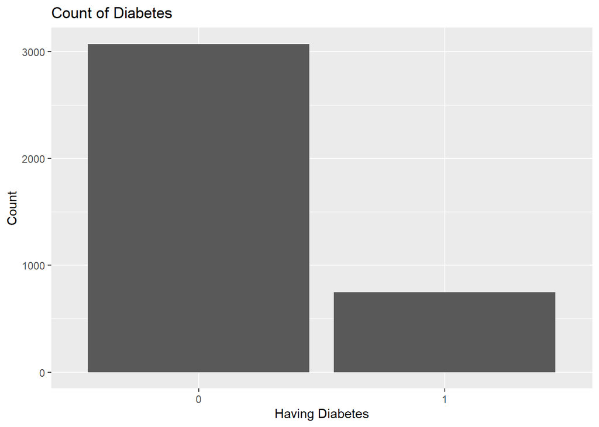

```r
ggplot(diabetes_data, aes(x = Diabetes_binary )) +
  geom_bar(stat = "count") +
  labs(title = "Count of Diabetes", x = "Having Diabetes", y = "Count")
```

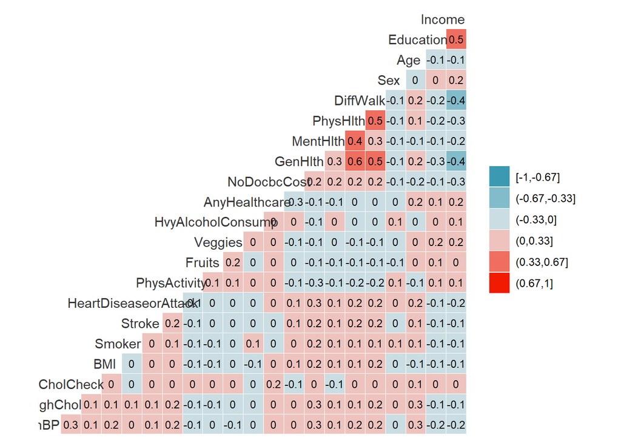

```r
ggcorr(diabetes_data,
       method = c("pairwise"),
       nbreaks = 6,
       hjust = 0.8,
       label = TRUE,
       label_size = 3,
       color = "grey20")
```

### Part 1.2 : Train & Test Split for Modeling (Scaled Split)

In order to train the model and then the test its performance, we need to split the data as training and test datasets. Before hand, we also need to scale the features (except the target feature) while using the K-Nearest-Neighbor algorithm since it is highly affected from feature’s scale.

In order not to mutate the main dataset, we’ll copy it and then make the scale and split operation.

```r
# Copying the main dataset and scaling the features
scaled_diabetes_data <- diabetes_data
scaled_diabetes_data[,-1] <- scale(scaled_diabetes_data[,-1])

validationIndex <- createDataPartition(scaled_diabetes_data$Diabetes_binary, p=0.70, list=FALSE)

knn_train <- scaled_diabetes_data[validationIndex,] # 70% of data to training
knn_test <- scaled_diabetes_data[-validationIndex,]

cat("Dimension of the main dataset:",dim(diabetes_data))
```

```
## Dimension of the main dataset: 3818 22
```

```r
cat("Dimension of the train dataset:",dim(knn_train))
```

```
## Dimension of the train dataset: 2673 22
```

```r
cat("Dimension of the test dataset:",dim(knn_test))
```

```
## Dimension of the test dataset: 1145 22
```

Dataset is scaled, has no missing and duplicated values. It is ready to be used in algorithms.

### Part 1.3 : kNN Algorithm (k-Nearest Neighbor)

Let’s start with the kNN algorithm. The algorithm is based on the idea that similar data points tend to be close to each other in the feature space. In other words, the class or value of an unknown data point can be predicted by examining its k-nearest neighbors.

There are two parameters to consider: the distance measure and the number of neighbors. We are mainly interested in two distance measures in this assignment: Euclidean and Manhattan Distance.

Let’s do the Cross Validation to find the optimal k (# of nearest neighbor):

```r
# 10-fold Cross Validation
trainControl <- trainControl(method="repeatedcv", number=10, repeats=3)
metric <- "Accuracy"

set.seed(10)
fit.knn <- train(Diabetes_binary~., data=knn_train, method="knn",
                 metric=metric ,trControl=trainControl)
knn.optimal.k <- fit.knn$bestTune # keep this Initial k for testing with knn() function in next section

print(fit.knn)
```

```
## k-Nearest Neighbors
##
## 2673 samples
##   21 predictor
##    2 classes: '0', '1'
##
## No pre-processing
## Resampling: Cross-Validated (10 fold, repeated 3 times)
## Summary of sample sizes: 2405, 2406, 2406, 2406, 2406, 2406, ...
## Resampling results across tuning parameters:
##
##   k  Accuracy   Kappa
##   5  0.7878813  0.1626608
##   7  0.7904928  0.1421343
##   9  0.8003526  0.1510310
##
## Accuracy was used to select the optimal model using the largest value.
## The final value used for the model was k = 9.
```

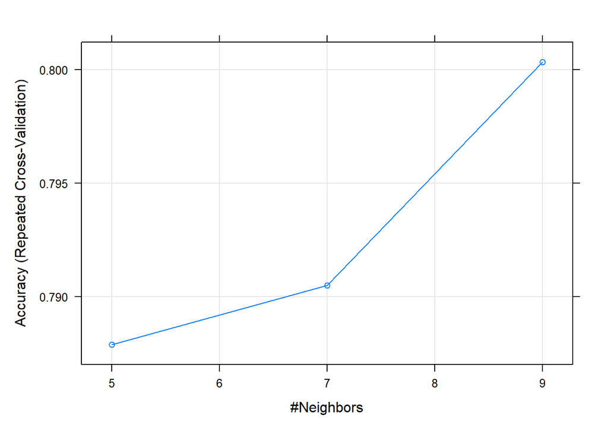

```r
# Plotting the Accuracy values with respect to the different k.
plot(fit.knn)
```

Accuracy was used to select the optimal model using the largest value. After the report of the CV and the plot shows that the final value used for the model was k = 9 and it is the optimum k value for the model.

Confusion matrix for k = 9 is as follows:

```r
prediction <- predict(fit.knn, newdata = knn_test)
cm_knn <- confusionMatrix(prediction, knn_test$Diabetes_binary)
print(cm_knn)
```

```
## Confusion Matrix and Statistics
##
##           Reference
## Prediction   0   1
##          0 873 191
##          1  48  33
##
##                Accuracy : 0.7913
##                  95% CI : (0.7666, 0.8145)
##     No Information Rate : 0.8044
##     P-Value [Acc > NIR] : 0.8754
##
##                   Kappa : 0.1255
##
##  Mcnemar's Test P-Value : <2e-16
##
##             Sensitivity : 0.9479
##             Specificity : 0.1473
##          Pos Pred Value : 0.8205
##          Neg Pred Value : 0.4074
##              Prevalence : 0.8044
##          Detection Rate : 0.7624
##    Detection Prevalence : 0.9293
##       Balanced Accuracy : 0.5476
##
##        'Positive' Class : 0
##
```

Let’s do the analysis for different types of k such as the floor of square root of the dataset size (row)

```r
initial_k <- sqrt(NROW(scaled_diabetes_data))
initial_k
```

```
## [1] 61.78997
```

```r
knn.floor <- knn(train=knn_train[,-1], test=knn_test[,-1],
                 cl=knn_train$Diabetes_binary, k=floor(initial_k))

# use confusion matrix to calculate accuracy
cm.floor <- confusionMatrix(knn_test$Diabetes_binary,knn.floor)
cm.floor
```

```
## Confusion Matrix and Statistics
##
##           Reference
## Prediction   0   1
##          0 916   5
##          1 215   9
##
##                Accuracy : 0.8079
##                  95% CI : (0.7838, 0.8303)
##     No Information Rate : 0.9878
##     P-Value [Acc > NIR] : 1
##
##                   Kappa : 0.0539
##
##  Mcnemar's Test P-Value : <2e-16
##
##             Sensitivity : 0.80990
##             Specificity : 0.64286
##          Pos Pred Value : 0.99457
##          Neg Pred Value : 0.04018
##              Prevalence : 0.98777
##          Detection Rate : 0.80000
##    Detection Prevalence : 0.80437
##       Balanced Accuracy : 0.72638
##
##        'Positive' Class : 0
##
```

Its accuracy is better but it is misleading since there is an imbalancing in the dataset. Meaning that there much mure “0” diabetes target values occur. This model was not able to identify the negative cases well.

Finally, lets also look at the model with Manhattan distance using `kknn` library.

```r
knn.manhattan <- train.kknn(Diabetes_binary ~ ., data = knn_train, ks = 9, scale = TRUE, distance = 1)
predictions.manhattan <- predict(knn.manhattan, newdata = knn_test)

cm.manhattan <- table(predictions.manhattan, knn_test$Diabetes_binary)
print(cm.manhattan)
```

```
##
## predictions.manhattan   0   1
##                     0 842 175
##                     1  79  49
```

```r
accuracy.manhattan <- sum(diag(cm.manhattan)) / sum(cm.manhattan)
print(paste("Accuracy for kNN with Manhattan Distance:", round(accuracy.manhattan,2)))
```

```
## [1] "Accuracy for kNN with Manhattan Distance: 0.78"
```

Performance of the `Manhattan kNN` is a little worse than the `Euclidean kNN`.

Thus, we decided that the best model that explains this dataset is the kNN with `k = 9 & distance = Euclidean`.

```r
knn.best <- knn(train=knn_train[,-1], test=knn_test[,-1], cl=knn_train$Diabetes_binary, k= 9)
cf <- confusionMatrix(knn_test$Diabetes_binary,knn.best)
print(cf)
```

```
## Confusion Matrix and Statistics
##
##           Reference
## Prediction   0   1
##          0 873  48
##          1 191  33
##
##                Accuracy : 0.7913
##                  95% CI : (0.7666, 0.8145)
##     No Information Rate : 0.9293
##     P-Value [Acc > NIR] : 1
##
##                   Kappa : 0.1255
##
##  Mcnemar's Test P-Value : <2e-16
##
##             Sensitivity : 0.8205
##             Specificity : 0.4074
##          Pos Pred Value : 0.9479
##          Neg Pred Value : 0.1473
##              Prevalence : 0.9293
##          Detection Rate : 0.7624
##    Detection Prevalence : 0.8044
##       Balanced Accuracy : 0.6139
##
##        'Positive' Class : 0
##
```

### Part 1.4 : Decision-Tree Algorithm

Let’s move with the second one which is the Decision Tree (DT) algorithm.

First, arranging the dataset in order not to mutate original one, we copy from it.

```r
# Copying the main dataset
diabetes_data_dt <- data.table(diabetes_data)

head(diabetes_data_dt)
```

```
##    Diabetes_binary HighBP HighChol CholCheck BMI Smoker Stroke
## 1:               0      1        1         1  40      1      0
## 2:               0      0        0         0  25      1      0
## 3:               0      1        1         1  28      0      0
## 4:               0      1        0         1  27      0      0
## 5:               0      1        1         1  24      0      0
## 6:               0      1        1         1  25      1      0
##    HeartDiseaseorAttack PhysActivity Fruits Veggies HvyAlcoholConsump
## 1:                    0            0      0       1                 0
## 2:                    0            1      0       0                 0
## 3:                    0            0      1       0                 0
## 4:                    0            1      1       1                 0
## 5:                    0            1      1       1                 0
## 6:                    0            1      1       1                 0
##    AnyHealthcare NoDocbcCost GenHlth MentHlth PhysHlth DiffWalk Sex Age
## 1:             1           0       5       18       15        1   0   9
## 2:             0           1       3        0        0        0   0   7
## 3:             1           1       5       30       30        1   0   9
## 4:             1           0       2        0        0        0   0  11
## 5:             1           0       2        3        0        0   0  11
## 6:             1           0       2        0        2        0   1  10
##    Education Income
## 1:         4      3
## 2:         6      1
## 3:         4      8
## 4:         3      6
## 5:         5      4
## 6:         6      8
```

```r
dim(diabetes_data_dt)
```

```
## [1] 3818   22
```

```r
# Remove rows with any NA values
diabetes_data_dt <- na.omit(diabetes_data_dt)
validationIndex <- createDataPartition(diabetes_data_dt$Diabetes_binary, p=0.70, list=FALSE)

dt_train <- diabetes_data_dt[validationIndex,] # 70% of data to training
dt_test <- diabetes_data_dt[-validationIndex,]

cat("Dimension of the main dataset:",dim(diabetes_data_dt))
```

```
## Dimension of the main dataset: 3818 22
```

```r
cat("Dimension of the train dataset:",dim(dt_train))
```

```
## Dimension of the train dataset: 2673 22
```

```r
cat("Dimension of the test dataset:",dim(dt_test))
```

```
## Dimension of the test dataset: 1145 22
```

Dataset is ready to be learned and now we are going to implement a manual cross validation to tune the hyperparameters for the decision tree and we are going to look at its Accuracy value in each iteration.

Assuming the tuning hyperparameter will be only the minimal number of observations per tree leaf. Setting complexity parameter to zero and minimum number of observations to split as the twice as the minimal number of observations per tree leaf.

In the end, we are going to store them in df to find the best model.

```r
# Create a data frame to store cross-validation results
cv_results <- data.frame(minbucket = numeric(), accuracy = numeric())

set.seed(15)

# Define a range of minsplit values to try
minbucket_values <- c(1, 5, 10, 15, 20, 25, 50)

# Perform cross-validation for each minbucket value
for (minbucket_val in minbucket_values) {
  # Create a decision tree model with the current minbucket value
  tree_model <- rpart(Diabetes_binary~.,diabetes_data_dt,method='class',
                      control=rpart.control(cp=0, minbucket = minbucket_val, minsplit = 2*minbucket_val))

  predictions <- predict(tree_model, newdata = dt_train, type = "class")
  correct_predictions <- sum(predictions == dt_train$Diabetes_binary)
  # Calculate accuracy
  accuracy <- round(correct_predictions / nrow(dt_train),5)

  # Store the results in the data frame
  cv_results <- rbind(cv_results, data.frame(minbucket = minbucket_val, accuracy = accuracy))
}

# Print the cross-validation results
print(cv_results)
```

```
##   minbucket accuracy
## 1         1  0.99963
## 2         5  0.88403
## 3        10  0.85148
## 4        15  0.83913
## 5        20  0.83165
## 6        25  0.82716
## 7        50  0.82604
```

Looks like the model with `minbucket` = 1 is the best model in terms of accuracy, lets also analyze its ROC, AUC and confusion matrix.

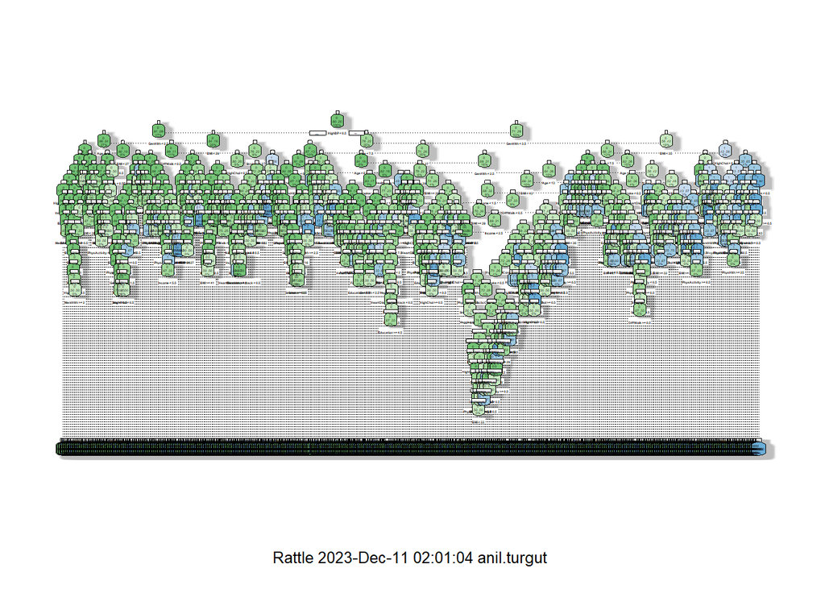

```r
# Optimum hyperparameter
minbucket_val <- 1
best_tree_model <- rpart(Diabetes_binary~.,diabetes_data_dt,method='class',
                    control=rpart.control(cp=0, minbucket = minbucket_val, minsplit = 2*minbucket_val))

fancyRpartPlot(best_tree_model)
```

Its confusion matrices with respect to training & test dataset are below. It successfully classifies the target values near 99%. Thus, it is the best model explaining this problem so far.

```r
predictions_model <- predict(best_tree_model, newdata = dt_train, type = "class")
cm_train <- confusionMatrix(predictions_model, dt_train$Diabetes_binary, positive="0")
cm_train
```

```
## Confusion Matrix and Statistics
##
##           Reference
## Prediction    0    1
##          0 2150    1
##          1    0  522
##
##                Accuracy : 0.9996
##                  95% CI : (0.9979, 1)
##     No Information Rate : 0.8043
##     P-Value [Acc > NIR] : <2e-16
##
##                   Kappa : 0.9988
##
##  Mcnemar's Test P-Value : 1
##
##             Sensitivity : 1.0000
##             Specificity : 0.9981
##          Pos Pred Value : 0.9995
##          Neg Pred Value : 1.0000
##              Prevalence : 0.8043
##          Detection Rate : 0.8043
##    Detection Prevalence : 0.8047
##       Balanced Accuracy : 0.9990
##
##        'Positive' Class : 0
##
```

```r
predictions_model.test <- predict(best_tree_model, newdata = dt_test, type = "class")
cm_test <- confusionMatrix(predictions_model.test, dt_test$Diabetes_binary, positive="0")
cm_test
```

```
## Confusion Matrix and Statistics
##
##           Reference
## Prediction   0   1
##          0 921   0
##          1   0 224
##
##                Accuracy : 1
##                  95% CI : (0.9968, 1)
##     No Information Rate : 0.8044
##     P-Value [Acc > NIR] : < 2.2e-16
##
##                   Kappa : 1
##
##  Mcnemar's Test P-Value : NA
##
##             Sensitivity : 1.0000
##             Specificity : 1.0000
##          Pos Pred Value : 1.0000
##          Neg Pred Value : 1.0000
##              Prevalence : 0.8044
##          Detection Rate : 0.8044
##    Detection Prevalence : 0.8044
##       Balanced Accuracy : 1.0000
##
##        'Positive' Class : 0
##
```

Finally, we can look its ROC curve and AUC score

[figure not shown]

```r
p1 <- predict(best_tree_model, dt_test, type = 'prob')[,2]
r <- multiclass.roc(dt_test$Diabetes_binary, p1, percent = TRUE)
roc <- r[['rocs']]
r1 <- roc[[1]]
plot.roc(r1,
         print.auc=TRUE,
         auc.polygon=TRUE,
         grid=c(0.1, 0.2),
         grid.col=c("green", "red"),
         max.auc.polygon=TRUE,
         auc.polygon.col="lightblue",
         print.thres=TRUE,
         main= 'ROC Curve')
```

### Part 1.5 : Random Forest Algorithm

Let’s move with the third one which is the Random Forest (RF) algorithm.

First, arranging the dataset in order not to mutate original one, we copy from it.

```r
# Copying the main dataset
diabetes_data_rf <- data.table(diabetes_data)

head(diabetes_data_rf)
```

```
##    Diabetes_binary HighBP HighChol CholCheck BMI Smoker Stroke
## 1:               0      1        1         1  40      1      0
## 2:               0      0        0         0  25      1      0
## 3:               0      1        1         1  28      0      0
## 4:               0      1        0         1  27      0      0
## 5:               0      1        1         1  24      0      0
## 6:               0      1        1         1  25      1      0
##    HeartDiseaseorAttack PhysActivity Fruits Veggies HvyAlcoholConsump
## 1:                    0            0      0       1                 0
## 2:                    0            1      0       0                 0
## 3:                    0            0      1       0                 0
## 4:                    0            1      1       1                 0
## 5:                    0            1      1       1                 0
## 6:                    0            1      1       1                 0
##    AnyHealthcare NoDocbcCost GenHlth MentHlth PhysHlth DiffWalk Sex Age
## 1:             1           0       5       18       15        1   0   9
## 2:             0           1       3        0        0        0   0   7
## 3:             1           1       5       30       30        1   0   9
## 4:             1           0       2        0        0        0   0  11
## 5:             1           0       2        3        0        0   0  11
## 6:             1           0       2        0        2        0   1  10
##    Education Income
## 1:         4      3
## 2:         6      1
## 3:         4      8
## 4:         3      6
## 5:         5      4
## 6:         6      8
```

```r
dim(diabetes_data_rf)
```

```
## [1] 3818   22
```

```r
diabetes_data_rf <- na.omit(diabetes_data_rf)
validationIndex <- createDataPartition(diabetes_data_rf$Diabetes_binary, p=0.70, list=FALSE)

rf_train <- diabetes_data_rf[validationIndex,] # 70% of data to training
rf_test <- diabetes_data_rf[-validationIndex,]

cat("Dimension of the main dataset:",dim(diabetes_data_rf))
```

```
## Dimension of the main dataset: 3818 22
```

```r
cat("Dimension of the train dataset:",dim(rf_train))
```

```
## Dimension of the train dataset: 2673 22
```

```r
cat("Dimension of the test dataset:",dim(rf_test))
```

```
## Dimension of the test dataset: 1145 22
```

Dataset is ready to be learned and now we are going to implement a manual cross validation to tune the hyperparameters for the random forest and we are going to look at its error value in each iteration.

Assuming the tuning hyperparameter will be only the effect of the ratio of the number of features evaluated at each split (mtry) and setting other parameters as J=500 and the minimal number of observations per tree leaf=5.

In the end, we are going to store them in table to find the best model.

```r
set.seed(50)
# Set the number of trees and nodesize
num_trees <- 500
min_obs_per_leaf <- 5

# Create a grid of mtry values to explore
mtry_values <- c(2, 4, 6, 8, 10, 15, 20)  # Add more values as needed

# Create an empty data frame to store results
rf_results <- data.frame(mtry = numeric(0), error_rate = numeric(0))

# Perform grid search
for (m in mtry_values) {
  # Train the Random Forest model
  rf_model <- randomForest(Diabetes_binary ~ ., data = rf_train,
                           ntree = num_trees, nodesize = min_obs_per_leaf, mtry = m)

  # Make predictions on the training set
  predictions <- predict(rf_model, dt_train)

  # Calculate the error rate (you may want to use a more appropriate metric)
  error_rate <- mean(predictions != rf_train$Diabetes_binary)

  # Store the results
  rf_results <- rbind(rf_results, data.frame(mtry = m, error_rate = error_rate))
}

# Print the results
print(rf_results)
```

```
##   mtry error_rate
## 1    2  0.2169847
## 2    4  0.2525253
## 3    6  0.2573887
## 4    8  0.2618780
## 5   10  0.2659933
## 6   15  0.2674897
## 7   20  0.2731014
```

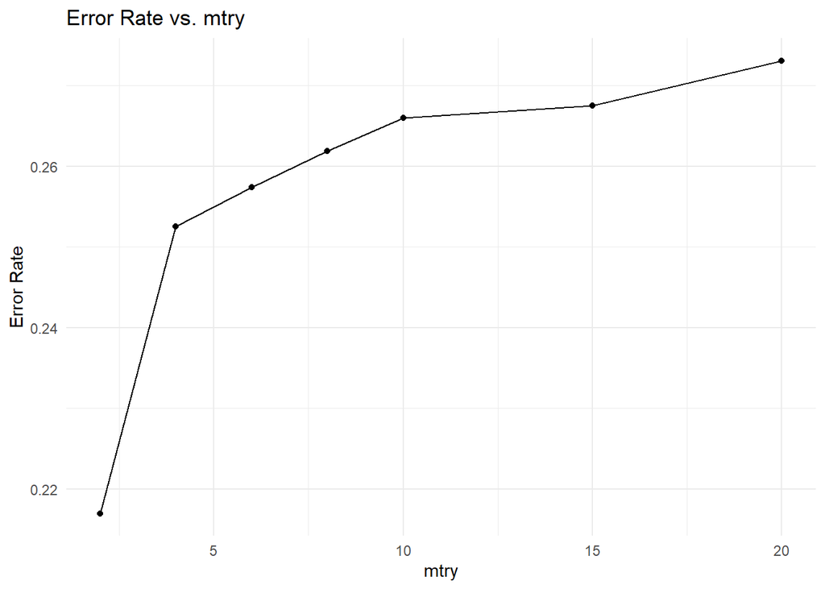

```r
# Create a line plot
ggplot(rf_results, aes(x = mtry, y = error_rate)) +
  geom_line() +
  geom_point() +
  labs(title = "Error Rate vs. mtry",
       x = "mtry",
       y = "Error Rate") +
  theme_minimal()
```

Looks like the model with `mtry` = 2 (given `ntree` = 500 & `nodesize` = 5) is the best model in terms of error rate, lets also analyze confusion matrix.

```r
best_rf_model <- randomForest(Diabetes_binary ~ ., data = rf_train,
                              ntree = num_trees, nodesize = min_obs_per_leaf, mtry = 2)

# Make predictions on the train set
rf_predictions.train <- predict(best_rf_model, newdata = rf_train)

# Create the confusion matrix
rf_confusion_matrix.train <- confusionMatrix(rf_predictions.train, rf_train$Diabetes_binary)

# Print the confusion matrix
print(rf_confusion_matrix.train)
```

```
## Confusion Matrix and Statistics
##
##           Reference
## Prediction    0    1
##          0 2150  383
##          1    0  140
##
##                Accuracy : 0.8567
##                  95% CI : (0.8429, 0.8698)
##     No Information Rate : 0.8043
##     P-Value [Acc > NIR] : 8.382e-13
##
##                   Kappa : 0.3703
##
##  Mcnemar's Test P-Value : < 2.2e-16
##
##             Sensitivity : 1.0000
##             Specificity : 0.2677
##          Pos Pred Value : 0.8488
##          Neg Pred Value : 1.0000
##              Prevalence : 0.8043
##          Detection Rate : 0.8043
##    Detection Prevalence : 0.9476
##       Balanced Accuracy : 0.6338
##
##        'Positive' Class : 0
##
```

```r
# Make predictions on the test set
rf_predictions.test <- predict(best_rf_model, newdata = rf_test)

# Create the confusion matrix
rf_confusion_matrix.test <- confusionMatrix(rf_predictions.test, rf_test$Diabetes_binary)

# Print the confusion matrix
print(rf_confusion_matrix.test)
```

```
## Confusion Matrix and Statistics
##
##           Reference
## Prediction   0   1
##          0 917 212
##          1   4  12
##
##                Accuracy : 0.8114
##                  95% CI : (0.7875, 0.8336)
##     No Information Rate : 0.8044
##     P-Value [Acc > NIR] : 0.29
##
##                   Kappa : 0.0759
##
##  Mcnemar's Test P-Value : <2e-16
##
##             Sensitivity : 0.99566
##             Specificity : 0.05357
##          Pos Pred Value : 0.81222
##          Neg Pred Value : 0.75000
##              Prevalence : 0.80437
##          Detection Rate : 0.80087
##    Detection Prevalence : 0.98603
##       Balanced Accuracy : 0.52461
##
##        'Positive' Class : 0
##
```

Its confusion matrices with respect to training & test dataset are above It classifies the target values near 85% but it has some difficulties while classifying the positive (‘1’) classes.

Finally, let’s look at the variable importance and the partial dependence plots. VarImp plot basically shows which feature has the most contribution to the model while it is improving (making purer). Partial Dependence plot is the plot showing the effect of selected feature to the predictions.

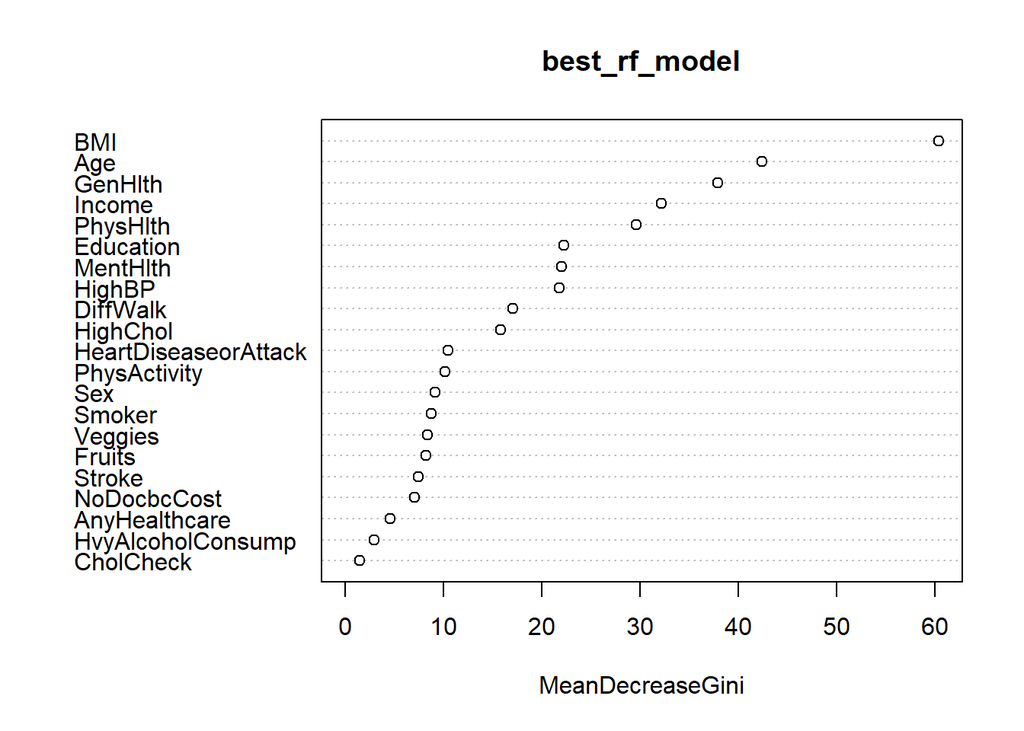

```r
# Plot variable importance
varImpPlot(best_rf_model)
```

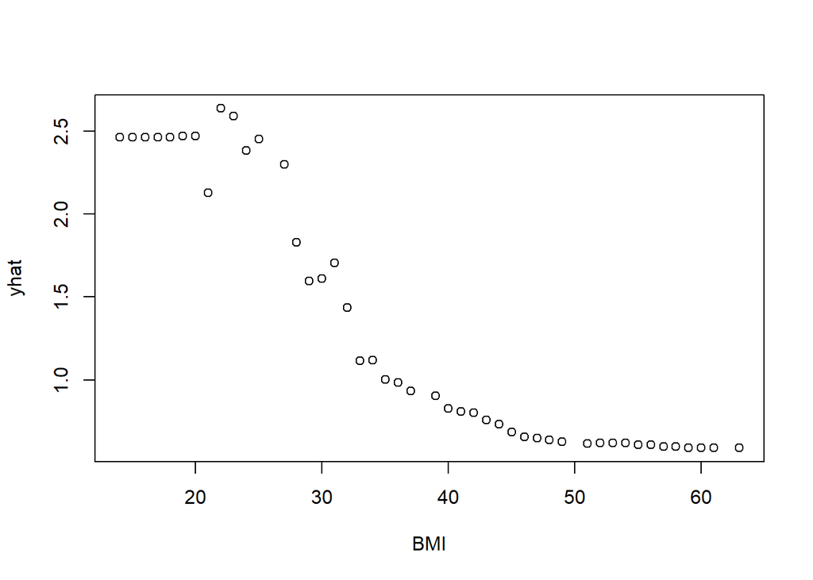

```r
# Create partial dependence plot
partial_plot <- partial(best_rf_model, pred.var = 'BMI', data = dt_test)

# Plot the partial dependence plot
plot(partial_plot)
```

### Part 1.6 : GBM Algorithm

First, arranging the dataset in order not to mutate original one, we copy from it.

```r
# Copying the main dataset
diabetes_data_gbm <- data.table(diabetes_data)
# Making the target value numeric to use in gbm
diabetes_data_gbm$Diabetes_binary <- as.numeric(diabetes_data_gbm$Diabetes_binary)
diabetes_data_gbm <- transform(diabetes_data_gbm, Diabetes_binary=Diabetes_binary-1)

head(diabetes_data_gbm)
```

```
##    Diabetes_binary HighBP HighChol CholCheck BMI Smoker Stroke
## 1:               0      1        1         1  40      1      0
## 2:               0      0        0         0  25      1      0
## 3:               0      1        1         1  28      0      0
## 4:               0      1        0         1  27      0      0
## 5:               0      1        1         1  24      0      0
## 6:               0      1        1         1  25      1      0
##    HeartDiseaseorAttack PhysActivity Fruits Veggies HvyAlcoholConsump
## 1:                    0            0      0       1                 0
## 2:                    0            1      0       0                 0
## 3:                    0            0      1       0                 0
## 4:                    0            1      1       1                 0
## 5:                    0            1      1       1                 0
## 6:                    0            1      1       1                 0
##    AnyHealthcare NoDocbcCost GenHlth MentHlth PhysHlth DiffWalk Sex Age
## 1:             1           0       5       18       15        1   0   9
## 2:             0           1       3        0        0        0   0   7
## 3:             1           1       5       30       30        1   0   9
## 4:             1           0       2        0        0        0   0  11
## 5:             1           0       2        3        0        0   0  11
## 6:             1           0       2        0        2        0   1  10
##    Education Income
## 1:         4      3
## 2:         6      1
## 3:         4      8
## 4:         3      6
## 5:         5      4
## 6:         6      8
```

```r
dim(diabetes_data_gbm)
```

```
## [1] 3818   22
```

```r
# Remove rows with any NA values
diabetes_data_gbm <- na.omit(diabetes_data_gbm)
validationIndex <- createDataPartition(diabetes_data_gbm$Diabetes_binary, p=0.70, list=FALSE)

gbm_train <- diabetes_data_gbm[validationIndex,] # 70% of data to training
gbm_test <- diabetes_data_gbm[-validationIndex,]

# To use in cross validation I have replace "0" with "no" else "yes"
gbm_train_revised <- gbm_train
gbm_test_revised <- gbm_test

gbm_train_revised$Diabetes_binary <- ifelse(gbm_train_revised$Diabetes_binary == "0", "no", "yes")
gbm_train_revised$Diabetes_binary <- as.factor(gbm_train_revised$Diabetes_binary )

gbm_test_revised$Diabetes_binary <- ifelse(gbm_test_revised$Diabetes_binary == "0", "no", "yes")
gbm_test_revised$Diabetes_binary <- as.factor(gbm_test_revised$Diabetes_binary )

cat("Dimension of the main dataset:",dim(diabetes_data_gbm))
```

```
## Dimension of the main dataset: 3818 22
```

```r
cat("Dimension of the train dataset:",dim(gbm_train))
```

```
## Dimension of the train dataset: 2673 22
```

```r
cat("Dimension of the test dataset:",dim(gbm_test))
```

```
## Dimension of the test dataset: 1145 22
```

In above, there are 2 train & test pairs occur. One will be used in the cross validation setting with replaced values “no” and “yes” and the other will be used to test the best model with tuned parameters.

Let’s tune the hyperparameters of the GBM with respect to the “ROC” value”.

We are mainly interested in tuning the depth (interaction.depth), the number of trees (n.trees) and the learning rate (shrinkage). Also, I have took a help from the lecture notes in this part.

```r
set.seed(10)

n_repeats=5
n_folds=10

fitControl=trainControl(method = "repeatedcv",
                        number = n_folds,
                        repeats = n_repeats,
                        classProbs=TRUE, summaryFunction=twoClassSummary)
## gradient boosting
gbmGrid=expand.grid(interaction.depth = c(3, 5),
                    n.trees = c(1:5)*100,
                    shrinkage = c(0.05,0.1),
                    n.minobsinnode = 10)
set.seed(1)
gbm_fit=train(Diabetes_binary ~ ., data = gbm_train_revised,
              method = "gbm",
              trControl = fitControl, metric='ROC',
              tuneGrid = gbmGrid,
              verbose=F) #verbose is an argument from gbm, prints to screen
gbm_fit
```

```
## Stochastic Gradient Boosting
##
## 2673 samples
##   21 predictor
##    2 classes: 'no', 'yes'
##
## No pre-processing
## Resampling: Cross-Validated (10 fold, repeated 5 times)
## Summary of sample sizes: 2406, 2406, 2406, 2404, 2405, 2406, ...
## Resampling results across tuning parameters:
##
##   shrinkage  interaction.depth  n.trees  ROC        Sens       Spec
##   0.05       3                  100      0.7756448  0.9576601  0.1964026
##   0.05       3                  200      0.7738290  0.9527580  0.2235714
##   0.05       3                  300      0.7709062  0.9482292  0.2315779
##   0.05       3                  400      0.7686719  0.9458725  0.2359416
##   0.05       3                  500      0.7656930  0.9422894  0.2384481
##   0.05       5                  100      0.7736531  0.9559629  0.2080130
##   0.05       5                  200      0.7693965  0.9468159  0.2297532
##   0.05       5                  300      0.7634534  0.9427593  0.2432078
##   0.05       5                  400      0.7590927  0.9405917  0.2518442
##   0.05       5                  500      0.7534202  0.9356878  0.2457208
##   0.10       3                  100      0.7711935  0.9496497  0.2228182
##   0.10       3                  200      0.7658005  0.9449313  0.2355714
##   0.10       3                  300      0.7618969  0.9403096  0.2489675
##   0.10       3                  400      0.7554462  0.9349367  0.2577403
##   0.10       3                  500      0.7506760  0.9324825  0.2552208
##   0.10       5                  100      0.7678796  0.9456808  0.2358896
##   0.10       5                  200      0.7570311  0.9351218  0.2460584
##   0.10       5                  300      0.7477010  0.9291811  0.2605779
##   0.10       5                  400      0.7392844  0.9210723  0.2598571
##   0.10       5                  500      0.7328353  0.9179573  0.2675130
##
## Tuning parameter 'n.minobsinnode' was held constant at a value of 10
## ROC was used to select the optimal model using the largest value.
## The final values used for the model were n.trees = 100, interaction.depth =
##  3, shrinkage = 0.05 and n.minobsinnode = 10.
```

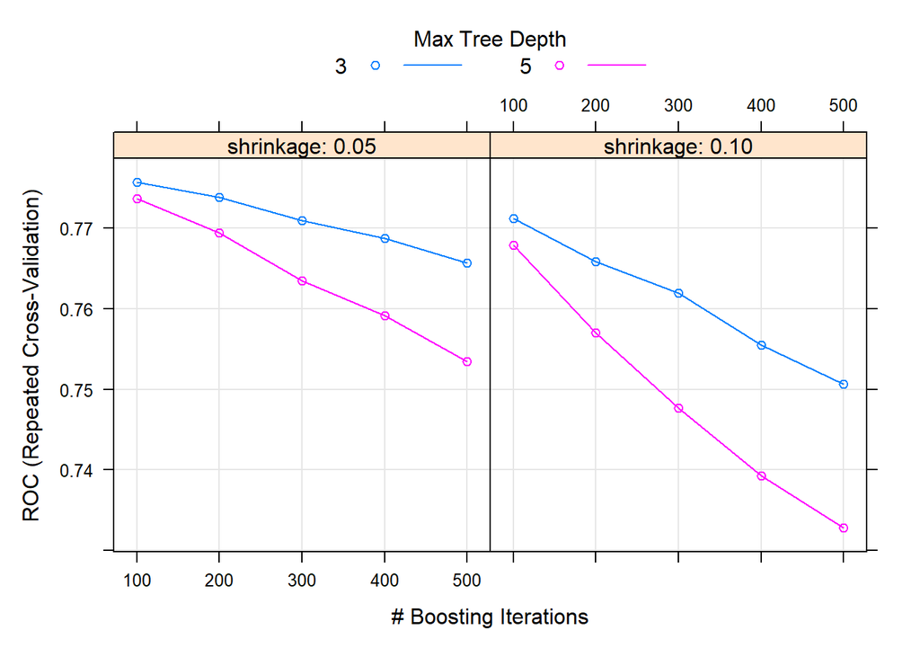

```r
plot(gbm_fit)
```

Selecting the best model is below:

```r
# select the best model
selected_gbm=tolerance(gbm_fit$results, metric = "ROC", tol = 2, maximize = TRUE)
gbm_fit$results[selected_gbm,]
```

```
##   shrinkage interaction.depth n.minobsinnode n.trees       ROC      Sens
## 1      0.05                 3             10     100 0.7756448 0.9576601
##        Spec      ROCSD     SensSD     SpecSD
## 1 0.1964026 0.03137304 0.01325657 0.04781317
```

Looks like the best GBM model with the parameters (Shrinkage = 0.05, depth = 3, n.trees = 100).

Let’s analyze this model with test data finally.

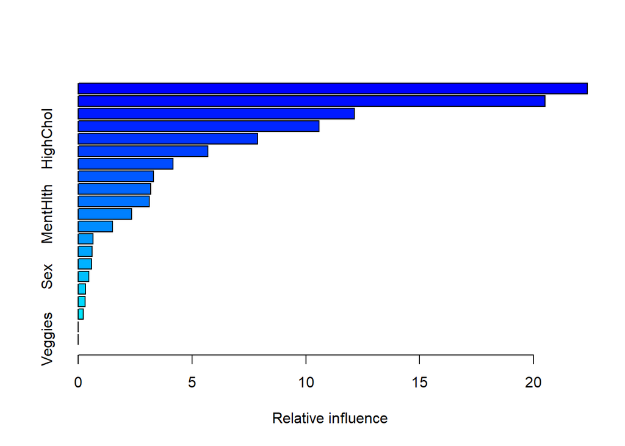

```
##                                       var    rel.inf
## GenHlth                           GenHlth 22.3618782
## BMI                                   BMI 20.5104441
## Age                                   Age 12.1274208
## HighBP                             HighBP 10.5797032
## HighChol                         HighChol  7.8821585
## Income                             Income  5.6918449
## DiffWalk                         DiffWalk  4.1697755
## PhysHlth                         PhysHlth  3.3015348
## Stroke                             Stroke  3.1931435
## HeartDiseaseorAttack HeartDiseaseorAttack  3.1209276
## MentHlth                         MentHlth  2.3605614
## Education                       Education  1.5056263
## NoDocbcCost                   NoDocbcCost  0.6490032
## Smoker                             Smoker  0.6173247
## PhysActivity                 PhysActivity  0.6031403
## Sex                                   Sex  0.4629330
## HvyAlcoholConsump       HvyAlcoholConsump  0.3207034
## CholCheck                       CholCheck  0.3156465
## AnyHealthcare               AnyHealthcare  0.2262302
## Fruits                             Fruits  0.0000000
## Veggies                           Veggies  0.0000000
```

```r
noftrees=100
depth=3
learning_rate=0.05

boosting_model=gbm(Diabetes_binary~., data=gbm_train,distribution = 'bernoulli', n.trees = noftrees,
                   interaction.depth = depth, n.minobsinnode = 10, shrinkage =learning_rate, cv.folds = 10)

summary(boosting_model)
```

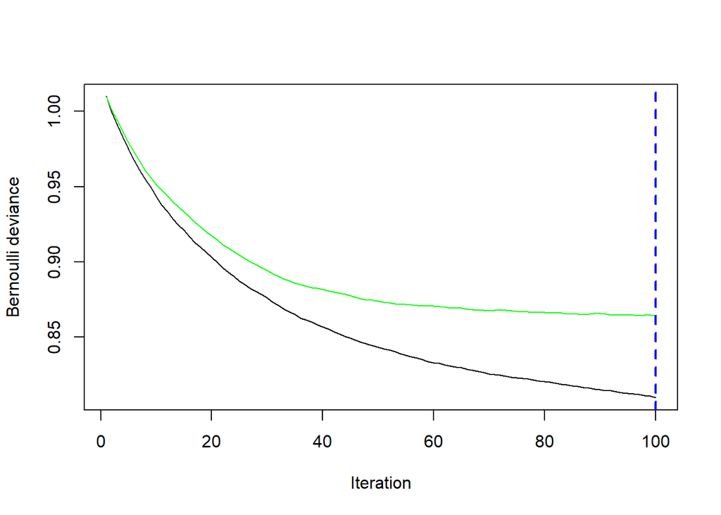

```
## [1] 100
```

```r
gbm.perf(boosting_model, method = "cv")
```

```r
prediction.train <- predict(boosting_model, newdata = gbm_train, type = "response")

confusion_data.train <- data.frame(actual = gbm_train$Diabetes_binary,
                             predicted = ifelse(prediction.train > 0.5,1,0))  # Assuming a threshold of 0.5 for binary classification

# Create a confusion matrix
conf_matrix.train <- confusionMatrix(as.factor(confusion_data.train$predicted), as.factor(confusion_data.train$actual))

print(conf_matrix.train)
```

```
## Confusion Matrix and Statistics
##
##           Reference
## Prediction    0    1
##          0 2054  422
##          1   67  130
##
##                Accuracy : 0.8171
##                  95% CI : (0.8019, 0.8315)
##     No Information Rate : 0.7935
##     P-Value [Acc > NIR] : 0.001241
##
##                   Kappa : 0.2676
##
##  Mcnemar's Test P-Value : < 2.2e-16
##
##             Sensitivity : 0.9684
##             Specificity : 0.2355
##          Pos Pred Value : 0.8296
##          Neg Pred Value : 0.6599
##              Prevalence : 0.7935
##          Detection Rate : 0.7684
##    Detection Prevalence : 0.9263
##       Balanced Accuracy : 0.6020
##
##        'Positive' Class : 0
##
```

Also analyzing with the test data:

```r
prediction.test <- predict(boosting_model, newdata = gbm_test, type = "response")

confusion_data.test <- data.frame(actual = gbm_test$Diabetes_binary,
                             predicted = ifelse(prediction.test > 0.5,1,0))  # Assuming a threshold of 0.5 for binary classification

# Create a confusion matrix
conf_matrix.test <- confusionMatrix(as.factor(confusion_data.test$predicted), as.factor(confusion_data.test$actual))

print(conf_matrix.test)
```

```
## Confusion Matrix and Statistics
##
##           Reference
## Prediction   0   1
##          0 921 164
##          1  29  31
##
##                Accuracy : 0.8314
##                  95% CI : (0.8085, 0.8527)
##     No Information Rate : 0.8297
##     P-Value [Acc > NIR] : 0.4564
##
##                   Kappa : 0.1772
##
##  Mcnemar's Test P-Value : <2e-16
##
##             Sensitivity : 0.9695
##             Specificity : 0.1590
##          Pos Pred Value : 0.8488
##          Neg Pred Value : 0.5167
##              Prevalence : 0.8297
##          Detection Rate : 0.8044
##    Detection Prevalence : 0.9476
##       Balanced Accuracy : 0.5642
##
##        'Positive' Class : 0
##
```

Results are not bad but not sufficient to explain problem yet.

Conclusion : We have worked on a dataset about the diagnosis of the diabetes and implemented 4 different learning algorithms with different hyperparameters. We concluded that the Decision Tree with `minbucket` = 1 is the algorithm that can explain or classifies the problem most well.

Comments:

kNN was the fastest algorithm to learn but it is not sufficient to identify diagnosis of the disease RandomForest and GBM has similar result metrics, but they took long time to be learned, especially GBM DT had the least cv, test errors. It can almost explain the whole test dataset, but it learned complex model. It might have difficulties with further non-seen datasets.

Let’s move on with the second dataset which is about the classification of the students’ success.

## Students Success Case

### Part 2.0 : Explaining the Students Success Case and loading the data.

A dataset created from a higher education institution (acquired from several disjoint databases) related to students enrolled in different undergraduate degrees, such as agronomy, design, education, nursing, journalism, management, social service, and technologies. The dataset includes information known at the time of student enrollment (academic path, demographics, and social-economic factors) and the students’ academic performance at the end of the first and second semesters. The data is used to build classification models to predict students’ dropout and academic success. The problem is formulated as a three category classification task, in which there is a strong imbalance towards one of the classes.

It will be seen that data is an imbalanced, multiclass classification problem. It will be analyzed below with different techniques.

In this part of the assignment, we mainly try to classify the student successes. Let’s start by loading the data to the environment.

```r
students_data_path <- paste0(data_path,"StudentSuccess/students.csv")

students_data <- read.csv(students_data_path, header = TRUE, sep = ";", quote = "\"")

head(students_data)
```

```
##   Marital.status Application.mode Application.order Course
## 1              1               17                 5    171
## 2              1               15                 1   9254
## 3              1                1                 5   9070
## 4              1               17                 2   9773
## 5              2               39                 1   8014
## 6              2               39                 1   9991
##   Daytime.evening.attendance. Previous.qualification
## 1                           1                      1
## 2                           1                      1
## 3                           1                      1
## 4                           1                      1
## 5                           0                      1
## 6                           0                     19
##   Previous.qualification..grade. Nacionality Mother.s.qualification
```

[output cut: 90 more lines]

### Part 2.1 : Data Analysis & Exploring Data & Preprocessing

```r
dim(students_data)
```

```
## [1] 4424   37
```

```r
str(students_data)
```

```
## 'data.frame':    4424 obs. of  37 variables:
##  $ Marital.status                                : int  1 1 1 1 2 2 1 1 1 1 ...
##  $ Application.mode                              : int  17 15 1 17 39 39 1 18 1 1 ...
##  $ Application.order                             : int  5 1 5 2 1 1 1 4 3 1 ...
##  $ Course                                        : int  171 9254 9070 9773 8014 9991 9500 9254 9238 9238 ...
##  $ Daytime.evening.attendance.                   : int  1 1 1 1 0 0 1 1 1 1 ...
##  $ Previous.qualification                        : int  1 1 1 1 1 19 1 1 1 1 ...
##  $ Previous.qualification..grade.                : num  122 160 122 122 100 ...
##  $ Nacionality                                   : int  1 1 1 1 1 1 1 1 62 1 ...
##  $ Mother.s.qualification                        : int  19 1 37 38 37 37 19 37 1 1 ...
##  $ Father.s.qualification                        : int  12 3 37 37 38 37 38 37 1 19 ...
##  $ Mother.s.occupation                           : int  5 3 9 5 9 9 7 9 9 4 ...
##  $ Father.s.occupation                           : int  9 3 9 3 9 7 10 9 9 7 ...
##  $ Admission.grade                               : num  127 142 125 120 142 ...
##  $ Displaced                                     : int  1 1 1 1 0 0 1 1 0 1 ...
```

[output cut: 23 more lines]

```r
summary(students_data)
```

```
##  Marital.status  Application.mode Application.order     Course
##  Min.   :1.000   Min.   : 1.00    Min.   :0.000     Min.   :  33
##  1st Qu.:1.000   1st Qu.: 1.00    1st Qu.:1.000     1st Qu.:9085
##  Median :1.000   Median :17.00    Median :1.000     Median :9238
##  Mean   :1.179   Mean   :18.67    Mean   :1.728     Mean   :8857
##  3rd Qu.:1.000   3rd Qu.:39.00    3rd Qu.:2.000     3rd Qu.:9556
##  Max.   :6.000   Max.   :57.00    Max.   :9.000     Max.   :9991
##  Daytime.evening.attendance. Previous.qualification
##  Min.   :0.0000              Min.   : 1.000
##  1st Qu.:1.0000              1st Qu.: 1.000
##  Median :1.0000              Median : 1.000
##  Mean   :0.8908              Mean   : 4.578
##  3rd Qu.:1.0000              3rd Qu.: 1.000
##  Max.   :1.0000              Max.   :43.000
##  Previous.qualification..grade.  Nacionality      Mother.s.qualification
##  Min.   : 95.0                  Min.   :  1.000   Min.   : 1.00
##  1st Qu.:125.0                  1st Qu.:  1.000   1st Qu.: 2.00
##  Median :133.1                  Median :  1.000   Median :19.00
##  Mean   :132.6                  Mean   :  1.873   Mean   :19.56
##  3rd Qu.:140.0                  3rd Qu.:  1.000   3rd Qu.:37.00
##  Max.   :190.0                  Max.   :109.000   Max.   :44.00
##  Father.s.qualification Mother.s.occupation Father.s.occupation Admission.grade
##  Min.   : 1.00          Min.   :  0.00      Min.   :  0.00      Min.   : 95.0
##  1st Qu.: 3.00          1st Qu.:  4.00      1st Qu.:  4.00      1st Qu.:117.9
##  Median :19.00          Median :  5.00      Median :  7.00      Median :126.1
##  Mean   :22.28          Mean   : 10.96      Mean   : 11.03      Mean   :127.0
##  3rd Qu.:37.00          3rd Qu.:  9.00      3rd Qu.:  9.00      3rd Qu.:134.8
##  Max.   :44.00          Max.   :194.00      Max.   :195.00      Max.   :190.0
##    Displaced      Educational.special.needs     Debtor
##  Min.   :0.0000   Min.   :0.00000           Min.   :0.0000
##  1st Qu.:0.0000   1st Qu.:0.00000           1st Qu.:0.0000
##  Median :1.0000   Median :0.00000           Median :0.0000
##  Mean   :0.5484   Mean   :0.01153           Mean   :0.1137
##  3rd Qu.:1.0000   3rd Qu.:0.00000           3rd Qu.:0.0000
##  Max.   :1.0000   Max.   :1.00000           Max.   :1.0000
##  Tuition.fees.up.to.date     Gender       Scholarship.holder Age.at.enrollment
##  Min.   :0.0000          Min.   :0.0000   Min.   :0.0000     Min.   :17.00
##  1st Qu.:1.0000          1st Qu.:0.0000   1st Qu.:0.0000     1st Qu.:19.00
##  Median :1.0000          Median :0.0000   Median :0.0000     Median :20.00
##  Mean   :0.8807          Mean   :0.3517   Mean   :0.2484     Mean   :23.27
```

[output cut: 50 more lines]

```
##  Max.   :18.57
##  Curricular.units.2nd.sem..without.evaluations. Unemployment.rate
##  Min.   : 0.0000                                Min.   : 7.60
##  1st Qu.: 0.0000                                1st Qu.: 9.40
##  Median : 0.0000                                Median :11.10
##  Mean   : 0.1503                                Mean   :11.57
##  3rd Qu.: 0.0000                                3rd Qu.:13.90
##  Max.   :12.0000                                Max.   :16.20
##  Inflation.rate        GDP               Target
##  Min.   :-0.800   Min.   :-4.060000   Length:4424
##  1st Qu.: 0.300   1st Qu.:-1.700000   Class :character
##  Median : 1.400   Median : 0.320000   Mode  :character
##  Mean   : 1.228   Mean   : 0.001969
##  3rd Qu.: 2.600   3rd Qu.: 1.790000
##  Max.   : 3.700   Max.   : 3.510000
```

Analyzing the data whether it has null values. If it has, then we need to handle the missing values.

```r
colSums(sapply(students_data, is.na))
```

```
##                                 Marital.status
##                                              0
##                               Application.mode
##                                              0
##                              Application.order
##                                              0
##                                         Course
##                                              0
##                    Daytime.evening.attendance.
##                                              0
##                         Previous.qualification
##                                              0
##                 Previous.qualification..grade.
##                                              0
##                                    Nacionality
##                                              0
##                         Mother.s.qualification
##                                              0
##                         Father.s.qualification
##                                              0
##                            Mother.s.occupation
##                                              0
##                            Father.s.occupation
##                                              0
##                                Admission.grade
##                                              0
##                                      Displaced
##                                              0
##                      Educational.special.needs
##                                              0
##                                         Debtor
##                                              0
##                        Tuition.fees.up.to.date
##                                              0
##                                         Gender
##                                              0
##                             Scholarship.holder
##                                              0
##                              Age.at.enrollment
##                                              0
```

[output cut: 19 more lines]

```
##                                              0
##            Curricular.units.2nd.sem..approved.
##                                              0
##               Curricular.units.2nd.sem..grade.
##                                              0
## Curricular.units.2nd.sem..without.evaluations.
##                                              0
##                              Unemployment.rate
##                                              0
##                                 Inflation.rate
##                                              0
##                                            GDP
##                                              0
##                                         Target
##                                              0
```

```r
skim(students_data)
```

Data summary

| Name | students_data |
| --- | --- |
| Number of rows | 4424 |
| Number of columns | 37 |
| _______________________ |  |
| Column type frequency: |  |
| character | 1 |
| numeric | 36 |
| ________________________ |  |
| Group variables | None |

**Variable type: character**

| skim_variable | n_missing | complete_rate | min | max | empty | n_unique | whitespace |
| --- | --- | --- | --- | --- | --- | --- | --- |
| Target | 0 | 1 | 7 | 8 | 0 | 3 | 0 |

**Variable type: numeric**

| skim_variable | n_missing | complete_rate | mean | sd | p0 | p25 | p50 | p75 | p100 | hist |
| --- | --- | --- | --- | --- | --- | --- | --- | --- | --- | --- |
| Marital.status | 0 | 1 | 1.18 | 0.61 | 1.00 | 1.00 | 1.00 | 1.00 | 6.00 | ▇▁▁▁▁ |
| Application.mode | 0 | 1 | 18.67 | 17.48 | 1.00 | 1.00 | 17.00 | 39.00 | 57.00 | ▇▅▁▆▁ |
| Application.order | 0 | 1 | 1.73 | 1.31 | 0.00 | 1.00 | 1.00 | 2.00 | 9.00 | ▇▂▁▁▁ |
| Course | 0 | 1 | 8856.64 | 2063.57 | 33.00 | 9085.00 | 9238.00 | 9556.00 | 9991.00 | ▁▁▁▁▇ |
| Daytime.evening.attendance. | 0 | 1 | 0.89 | 0.31 | 0.00 | 1.00 | 1.00 | 1.00 | 1.00 | ▁▁▁▁▇ |
| Previous.qualification | 0 | 1 | 4.58 | 10.22 | 1.00 | 1.00 | 1.00 | 1.00 | 43.00 | ▇▁▁▁▁ |
| Previous.qualification..grade. | 0 | 1 | 132.61 | 13.19 | 95.00 | 125.00 | 133.10 | 140.00 | 190.00 | ▁▇▇▁▁ |
| Nacionality | 0 | 1 | 1.87 | 6.91 | 1.00 | 1.00 | 1.00 | 1.00 | 109.00 | ▇▁▁▁▁ |
| Mother.s.qualification | 0 | 1 | 19.56 | 15.60 | 1.00 | 2.00 | 19.00 | 37.00 | 44.00 | ▇▁▅▁▇ |
| Father.s.qualification | 0 | 1 | 22.28 | 15.34 | 1.00 | 3.00 | 19.00 | 37.00 | 44.00 | ▆▁▅▁▇ |
| Mother.s.occupation | 0 | 1 | 10.96 | 26.42 | 0.00 | 4.00 | 5.00 | 9.00 | 194.00 | ▇▁▁▁▁ |
| Father.s.occupation | 0 | 1 | 11.03 | 25.26 | 0.00 | 4.00 | 7.00 | 9.00 | 195.00 | ▇▁▁▁▁ |
| Admission.grade | 0 | 1 | 126.98 | 14.48 | 95.00 | 117.90 | 126.10 | 134.80 | 190.00 | ▂▇▃▁▁ |
| Displaced | 0 | 1 | 0.55 | 0.50 | 0.00 | 0.00 | 1.00 | 1.00 | 1.00 | ▆▁▁▁▇ |
| Educational.special.needs | 0 | 1 | 0.01 | 0.11 | 0.00 | 0.00 | 0.00 | 0.00 | 1.00 | ▇▁▁▁▁ |
| Debtor | 0 | 1 | 0.11 | 0.32 | 0.00 | 0.00 | 0.00 | 0.00 | 1.00 | ▇▁▁▁▁ |
| Tuition.fees.up.to.date | 0 | 1 | 0.88 | 0.32 | 0.00 | 1.00 | 1.00 | 1.00 | 1.00 | ▁▁▁▁▇ |
| Gender | 0 | 1 | 0.35 | 0.48 | 0.00 | 0.00 | 0.00 | 1.00 | 1.00 | ▇▁▁▁▅ |
| Scholarship.holder | 0 | 1 | 0.25 | 0.43 | 0.00 | 0.00 | 0.00 | 0.00 | 1.00 | ▇▁▁▁▂ |
| Age.at.enrollment | 0 | 1 | 23.27 | 7.59 | 17.00 | 19.00 | 20.00 | 25.00 | 70.00 | ▇▁▁▁▁ |
| International | 0 | 1 | 0.02 | 0.16 | 0.00 | 0.00 | 0.00 | 0.00 | 1.00 | ▇▁▁▁▁ |
| Curricular.units.1st.sem..credited. | 0 | 1 | 0.71 | 2.36 | 0.00 | 0.00 | 0.00 | 0.00 | 20.00 | ▇▁▁▁▁ |
| Curricular.units.1st.sem..enrolled. | 0 | 1 | 6.27 | 2.48 | 0.00 | 5.00 | 6.00 | 7.00 | 26.00 | ▃▇▁▁▁ |
| Curricular.units.1st.sem..evaluations. | 0 | 1 | 8.30 | 4.18 | 0.00 | 6.00 | 8.00 | 10.00 | 45.00 | ▇▃▁▁▁ |
| Curricular.units.1st.sem..approved. | 0 | 1 | 4.71 | 3.09 | 0.00 | 3.00 | 5.00 | 6.00 | 26.00 | ▇▆▁▁▁ |
| Curricular.units.1st.sem..grade. | 0 | 1 | 10.64 | 4.84 | 0.00 | 11.00 | 12.29 | 13.40 | 18.88 | ▂▁▂▇▁ |
| Curricular.units.1st.sem..without.evaluations. | 0 | 1 | 0.14 | 0.69 | 0.00 | 0.00 | 0.00 | 0.00 | 12.00 | ▇▁▁▁▁ |
| Curricular.units.2nd.sem..credited. | 0 | 1 | 0.54 | 1.92 | 0.00 | 0.00 | 0.00 | 0.00 | 19.00 | ▇▁▁▁▁ |
| Curricular.units.2nd.sem..enrolled. | 0 | 1 | 6.23 | 2.20 | 0.00 | 5.00 | 6.00 | 7.00 | 23.00 | ▁▇▁▁▁ |
| Curricular.units.2nd.sem..evaluations. | 0 | 1 | 8.06 | 3.95 | 0.00 | 6.00 | 8.00 | 10.00 | 33.00 | ▃▇▁▁▁ |
| Curricular.units.2nd.sem..approved. | 0 | 1 | 4.44 | 3.01 | 0.00 | 2.00 | 5.00 | 6.00 | 20.00 | ▆▇▁▁▁ |
| Curricular.units.2nd.sem..grade. | 0 | 1 | 10.23 | 5.21 | 0.00 | 10.75 | 12.20 | 13.33 | 18.57 | ▂▁▁▇▁ |
| Curricular.units.2nd.sem..without.evaluations. | 0 | 1 | 0.15 | 0.75 | 0.00 | 0.00 | 0.00 | 0.00 | 12.00 | ▇▁▁▁▁ |
| Unemployment.rate | 0 | 1 | 11.57 | 2.66 | 7.60 | 9.40 | 11.10 | 13.90 | 16.20 | ▆▆▇▂▅ |
| Inflation.rate | 0 | 1 | 1.23 | 1.38 | -0.80 | 0.30 | 1.40 | 2.60 | 3.70 | ▆▇▆▆▃ |
| GDP | 0 | 1 | 0.00 | 2.27 | -4.06 | -1.70 | 0.32 | 1.79 | 3.51 | ▆▂▆▇▅ |

Can be seen in the data, there is no missing values, which is a good sign for us. First, we need to factorize the target value `Target`. Then, we also need to get rid of the duplicate values.

```r
students_data$Target <- as.factor(students_data$Target)

students_data <- students_data[!duplicated(students_data), ]
```

We are ready to move on. Let’s make some visualizations to understand data more. It can be seen that There is an imbalance in the class (target) variable between `Graduate` and `Enrolled`.

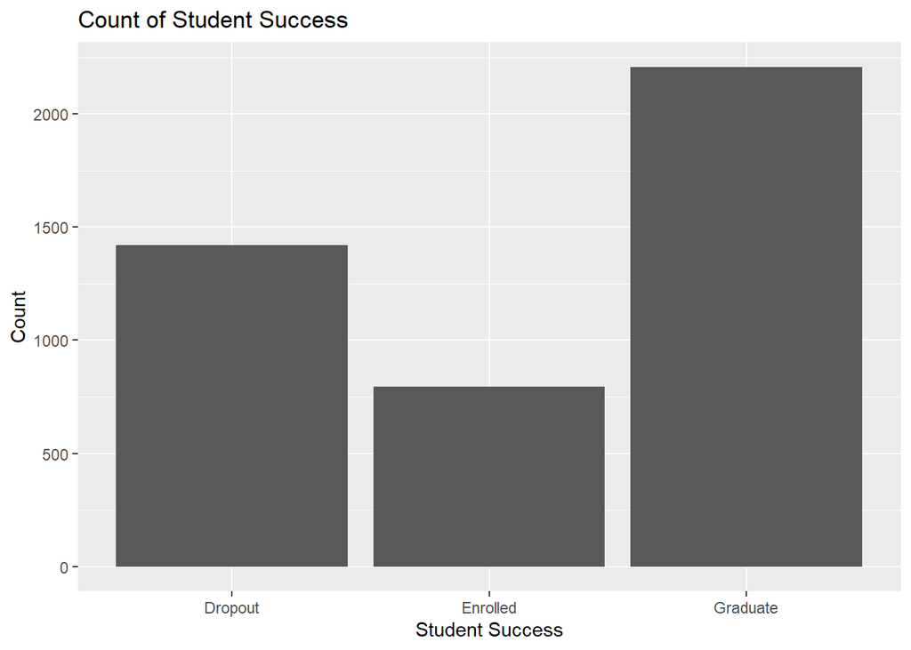

```r
ggplot(students_data, aes(x = Target )) +
  geom_bar(stat = "count") +
  labs(title = "Count of Student Success", x = "Student Success", y = "Count")
```

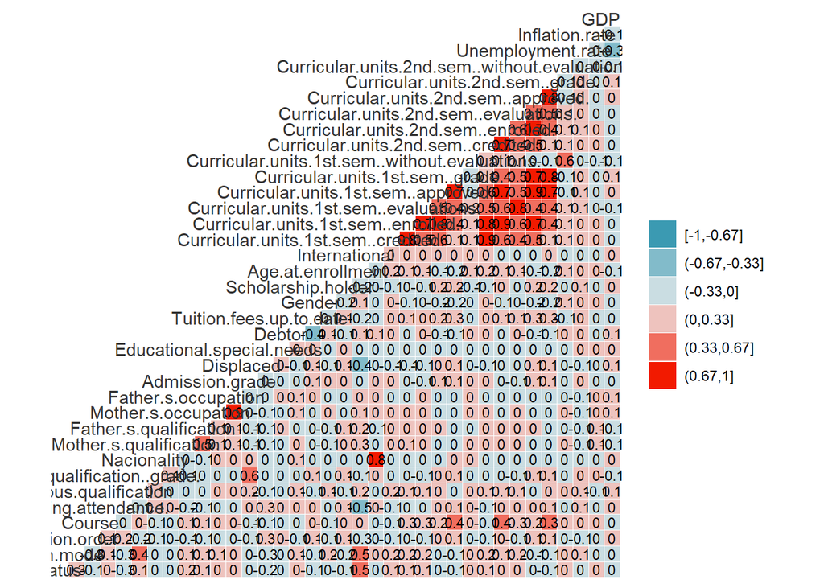

```r
ggcorr(students_data,
       method = c("pairwise"),
       nbreaks = 6,
       hjust = 0.8,
       label = TRUE,
       label_size = 3,
       color = "grey20")
```

### Part 2.2 : Train & Test Split for Modeling (Scaled Split)

In order to train the model and then the test its performance, we need to split the data as training and test datasets. Before hand, we also need to scale the features (except the target feature) while using the K-Nearest-Neighbor algorithm since it is highly affected from feature’s scale.

In order not to mutate the main dataset, we’ll copy it and then make the scale and split operation.

```r
scaled_students_data <- students_data
scaled_students_data[,-37] <- scale(scaled_students_data[,-37])

validationIndex <- createDataPartition(scaled_students_data$Target, p=0.70, list=FALSE)

knn_train <- scaled_students_data[validationIndex,] # 70% of data to training
knn_test <- scaled_students_data[-validationIndex,]


cat("Dimension of the main dataset:",dim(scaled_students_data))
```

```
## Dimension of the main dataset: 4424 37
```

```r
cat("Dimension of the train dataset:",dim(knn_train))
```

```
## Dimension of the train dataset: 3098 37
```

```r
cat("Dimension of the test dataset:",dim(knn_test))
```

```
## Dimension of the test dataset: 1326 37
```

Dataset is scaled, has no missing and duplicated values. It is ready to be used in algorithms.

### Part 2.3 : kNN Algorithm (k-Nearest Neighbor)

Let’s start with the kNN algorithm. The algorithm is based on the idea that similar data points tend to be close to each other in the feature space. In other words, the class or value of an unknown data point can be predicted by examining its k-nearest neighbors.

There are two parameters to consider: the distance measure and the number of neighbors. We are mainly interested in two distance measures in this assignment: Euclidean and Manhattan Distance.

Let’s do the Cross Validation to find the optimal k (# of nearest neighbor):

```r
# 10-fold Cross Validation
trainControl <- trainControl(method="repeatedcv", number=10, repeats=5)
metric <- "Accuracy"
set.seed(8)

# kNN Part
fit.knn <- train(Target~., data=knn_train, method="knn",
                 metric=metric ,trControl=trainControl)
knn.optimal.k <- fit.knn$bestTune # keep this Initial k for testing with knn() function in next section

print(fit.knn)
```

```
## k-Nearest Neighbors
##
## 3098 samples
##   36 predictor
##    3 classes: 'Dropout', 'Enrolled', 'Graduate'
##
## No pre-processing
## Resampling: Cross-Validated (10 fold, repeated 5 times)
## Summary of sample sizes: 2787, 2789, 2789, 2788, 2789, 2789, ...
## Resampling results across tuning parameters:
##
##   k  Accuracy   Kappa
##   5  0.6939244  0.4749923
##   7  0.7025141  0.4842424
##   9  0.7030373  0.4816328
##
## Accuracy was used to select the optimal model using the largest value.
## The final value used for the model was k = 9.
```

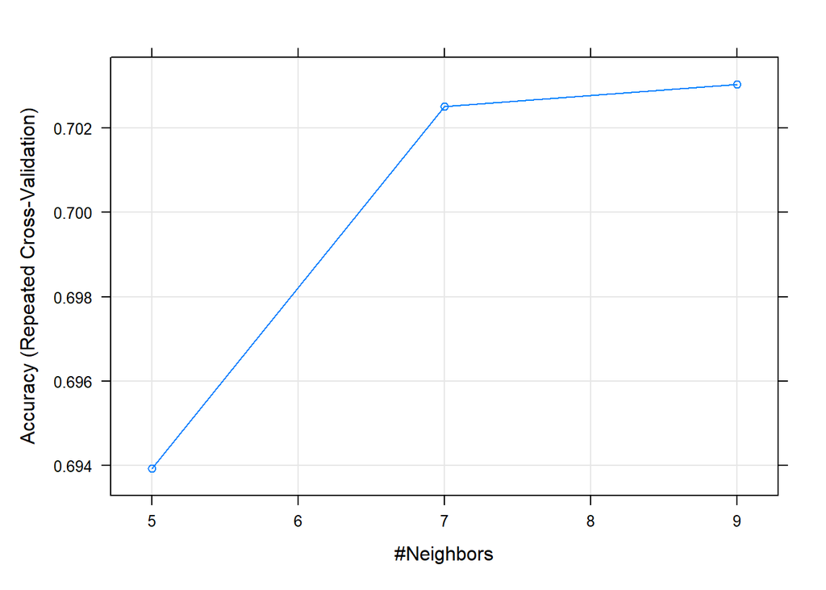

```r
plot(fit.knn)
```

Accuracy was used to select the optimal model using the largest value. After the report of the CV and the plot shows that the final value used for the model was k = 9 and it is the optimum k value for the model.

Confusion matrix for k = 9 is as follows:

```r
prediction <- predict(fit.knn, newdata = knn_test)
cm_knn <- confusionMatrix(prediction, knn_test$Target)
print(cm_knn)
```

```
## Confusion Matrix and Statistics
##
##           Reference
## Prediction Dropout Enrolled Graduate
##   Dropout      275       38       21
##   Enrolled      28       35       25
##   Graduate     123      165      616
##
## Overall Statistics
##
##                Accuracy : 0.6983
##                  95% CI : (0.6728, 0.723)
##     No Information Rate : 0.4992
##     P-Value [Acc > NIR] : < 2.2e-16
##
##                   Kappa : 0.4678
##
##  Mcnemar's Test P-Value : < 2.2e-16
##
## Statistics by Class:
##
##                      Class: Dropout Class: Enrolled Class: Graduate
## Sensitivity                  0.6455         0.14706          0.9305
## Specificity                  0.9344         0.95129          0.5663
## Pos Pred Value               0.8234         0.39773          0.6814
## Neg Pred Value               0.8478         0.83603          0.8910
## Prevalence                   0.3213         0.17949          0.4992
## Detection Rate               0.2074         0.02640          0.4646
## Detection Prevalence         0.2519         0.06637          0.6817
## Balanced Accuracy            0.7900         0.54917          0.7484
```

Let’s do the analysis for different types of k such as the floor of square root of the dataset size (row)

```r
initial_k <- sqrt(NROW(scaled_students_data))
initial_k
```

```
## [1] 66.51316
```

```r
knn.floor <- knn(train=knn_train[,-37], test=knn_test[,-37],
                 cl=knn_train$Target, k=floor(initial_k))

# use confusion matrix to calculate accuracy
cm.floor <- confusionMatrix(knn_test$Target,knn.floor)
cm.floor
```

```
## Confusion Matrix and Statistics
##
##           Reference
## Prediction Dropout Enrolled Graduate
##   Dropout      259       15      152
##   Enrolled      29        8      201
##   Graduate       6        0      656
##
## Overall Statistics
##
##                Accuracy : 0.6961
##                  95% CI : (0.6705, 0.7208)
##     No Information Rate : 0.7609
##     P-Value [Acc > NIR] : 1
##
##                   Kappa : 0.4431
##
##  Mcnemar's Test P-Value : <2e-16
##
## Statistics by Class:
##
##                      Class: Dropout Class: Enrolled Class: Graduate
## Sensitivity                  0.8810        0.347826          0.6501
## Specificity                  0.8382        0.823484          0.9811
## Pos Pred Value               0.6080        0.033613          0.9909
## Neg Pred Value               0.9611        0.986213          0.4684
## Prevalence                   0.2217        0.017345          0.7609
## Detection Rate               0.1953        0.006033          0.4947
## Detection Prevalence         0.3213        0.179487          0.4992
## Balanced Accuracy            0.8596        0.585655          0.8156
```

Its accuracy is similar (relatively lower) but it is misleading since model was not able to identify the Enrolled and Dropout well.

Finally, lets also look at the model with Manhattan distance using `kknn` library.

```r
knn.manhattan <- train.kknn(Target ~ ., data = knn_train, ks = 9, scale = TRUE, distance = 1)
predictions.manhattan <- predict(knn.manhattan, newdata = knn_test)

cm.manhattan <- table(predictions.manhattan, knn_test$Target)
print(cm.manhattan)
```

```
##
## predictions.manhattan Dropout Enrolled Graduate
##              Dropout      293       54       22
##              Enrolled      37       60       40
##              Graduate      96      124      600
```

```r
accuracy.manhattan <- sum(diag(cm.manhattan)) / sum(cm.manhattan)
print(paste("Accuracy for kNN with Manhattan Distance:", round(accuracy.manhattan,2)))
```

```
## [1] "Accuracy for kNN with Manhattan Distance: 0.72"
```

Performance of the `Manhattan kNN` is a little better than the `Euclidean kNN`. Even the accuracy is similar, classification of negative cases like droput and enrolled are better. Manhattan Distance is a Minkovski Distance with r = 1 and it looks like fit well in this dataset.

Thus, we decided that the best model that explains this dataset is the kNN with `k = 9 & distance = Manhattan`.

### Part 2.4 : Decision Tree Algorithm

Let’s move with the second one which is the Decision Tree (DT) algorithm.

First, arranging the dataset in order not to mutate original one, we copy from it.

```r
# Copying the main dataset
students_data_dt <- data.table(students_data)

head(students_data_dt)
```

```
##    Marital.status Application.mode Application.order Course
## 1:              1               17                 5    171
## 2:              1               15                 1   9254
## 3:              1                1                 5   9070
## 4:              1               17                 2   9773
## 5:              2               39                 1   8014
## 6:              2               39                 1   9991
##    Daytime.evening.attendance. Previous.qualification
## 1:                           1                      1
## 2:                           1                      1
## 3:                           1                      1
## 4:                           1                      1
## 5:                           0                      1
## 6:                           0                     19
##    Previous.qualification..grade. Nacionality Mother.s.qualification
```

[output cut: 90 more lines]

```r
dim(students_data_dt)
```

```
## [1] 4424   37
```

```r
# Remove rows with any NA values
students_data_dt <- na.omit(students_data_dt)
validationIndex <- createDataPartition(students_data_dt$Target, p=0.70, list=FALSE)

dt_train <- students_data_dt[validationIndex,] # 70% of data to training
dt_test <- students_data_dt[-validationIndex,]

cat("Dimension of the main dataset:",dim(students_data_dt))
```

```
## Dimension of the main dataset: 4424 37
```

```r
cat("Dimension of the train dataset:",dim(dt_train))
```

```
## Dimension of the train dataset: 3098 37
```

```r
cat("Dimension of the test dataset:",dim(dt_test))
```

```
## Dimension of the test dataset: 1326 37
```

Dataset is ready to be learned and now we are going to implement a manual cross validation to tune the hyperparameters for the decision tree and we are going to look at its Accuracy value in each iteration.

Assuming the tuning hyperparameter will be only the minimal number of observations per tree leaf. Setting complexity parameter to zero and minimum number of observations to split as the twice as the minimal number of observations per tree leaf.

In the end, we are going to store them in df to find the best model.

```r
# Create a data frame to store cross-validation results
cv_results <- data.frame(minbucket = numeric(), accuracy = numeric())

set.seed(10)

# Define a range of minsplit values to try
minbucket_values <- c(1, 5, 10, 15, 20)

# Perform cross-validation for each minbucket value
for (minbucket_val in minbucket_values) {
  # Create a decision tree model with the current minbucket value
  tree_model <- rpart(Target~.,dt_train,method='class',
                      control=rpart.control(cp=0, minbucket = minbucket_val, minsplit = 2*minbucket_val))

  predictions <- predict(tree_model, newdata = dt_train, type = "class")
  correct_predictions <- sum(predictions == dt_train$Target)
  # Calculate accuracy
  accuracy <- round(correct_predictions / nrow(dt_train),5)

  # Store the results in the data frame
  cv_results <- rbind(cv_results, data.frame(minbucket = minbucket_val, accuracy = accuracy))
}

# Print the cross-validation results
print(cv_results)
```

```
##   minbucket accuracy
## 1         1  1.00000
## 2         5  0.86475
## 3        10  0.82634
## 4        15  0.80730
## 5        20  0.78954
```

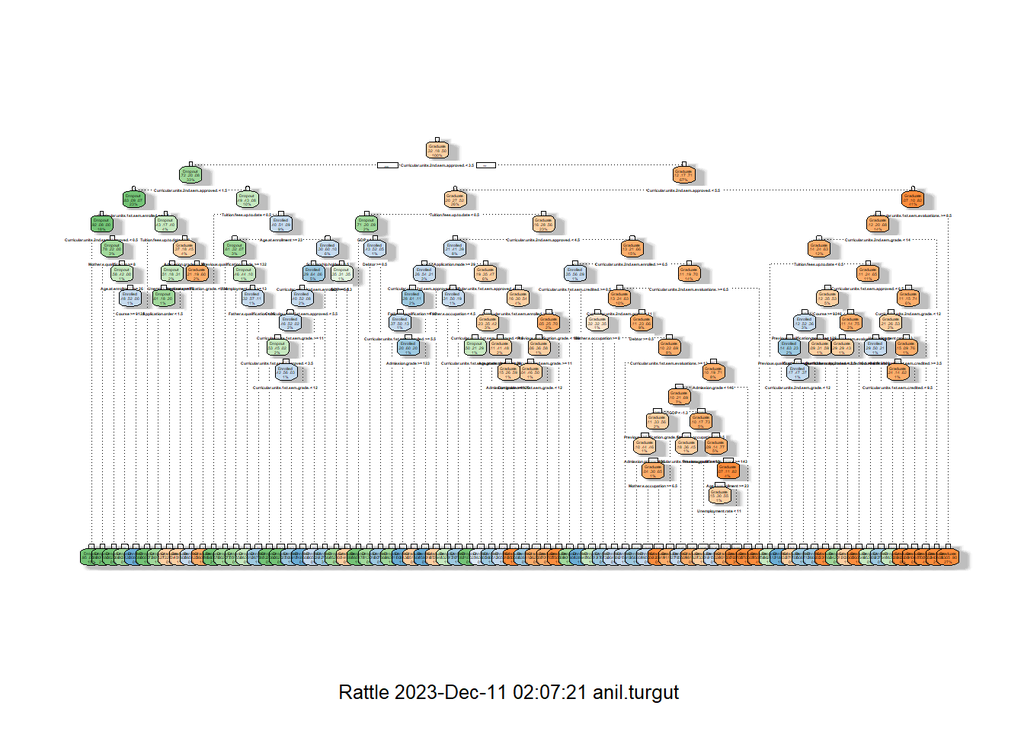

```r
minbucket_val <- 10
best_tree_model <- rpart(Target~.,dt_train,method='class',
                         control=rpart.control(cp=0, minbucket = minbucket_val, minsplit = 2*minbucket_val))

fancyRpartPlot(best_tree_model)
```

Its confusion matrices with respect to training & test dataset are below. It successfully classifies the target values near 75%.

```r
predictions_model <- predict(best_tree_model, newdata = dt_train, type = "class")
cm_train <- confusionMatrix(predictions_model, dt_train$Target)
cm_train
```

```
## Confusion Matrix and Statistics
##
##           Reference
## Prediction Dropout Enrolled Graduate
##   Dropout      811       99       46
##   Enrolled      69      331       83
##   Graduate     115      126     1418
##
## Overall Statistics
##
##                Accuracy : 0.8263
##                  95% CI : (0.8125, 0.8395)
##     No Information Rate : 0.4994
##     P-Value [Acc > NIR] : < 2.2e-16
##
##                   Kappa : 0.7132
##
##  Mcnemar's Test P-Value : 1.684e-09
##
## Statistics by Class:
##
##                      Class: Dropout Class: Enrolled Class: Graduate
## Sensitivity                  0.8151          0.5953          0.9166
## Specificity                  0.9311          0.9402          0.8446
## Pos Pred Value               0.8483          0.6853          0.8547
## Neg Pred Value               0.9141          0.9140          0.9104
## Prevalence                   0.3212          0.1795          0.4994
## Detection Rate               0.2618          0.1068          0.4577
## Detection Prevalence         0.3086          0.1559          0.5355
## Balanced Accuracy            0.8731          0.7678          0.8806
```

```r
predictions_model.test <- predict(best_tree_model, newdata = dt_test, type = "class")
cm_test <- confusionMatrix(predictions_model.test, dt_test$Target)
cm_test
```

```
## Confusion Matrix and Statistics
##
##           Reference
## Prediction Dropout Enrolled Graduate
##   Dropout      323       63       31
##   Enrolled      47       99       81
##   Graduate      56       76      550
##
## Overall Statistics
##
##                Accuracy : 0.733
##                  95% CI : (0.7083, 0.7567)
##     No Information Rate : 0.4992
##     P-Value [Acc > NIR] : < 2e-16
##
##                   Kappa : 0.5634
##
##  Mcnemar's Test P-Value : 0.02159
##
## Statistics by Class:
##
##                      Class: Dropout Class: Enrolled Class: Graduate
## Sensitivity                  0.7582         0.41597          0.8308
## Specificity                  0.8956         0.88235          0.8012
## Pos Pred Value               0.7746         0.43612          0.8065
## Neg Pred Value               0.8867         0.87352          0.8261
## Prevalence                   0.3213         0.17949          0.4992
## Detection Rate               0.2436         0.07466          0.4148
## Detection Prevalence         0.3145         0.17119          0.5143
## Balanced Accuracy            0.8269         0.64916          0.8160
```

Finally, we can look its ROC curve and AUC score

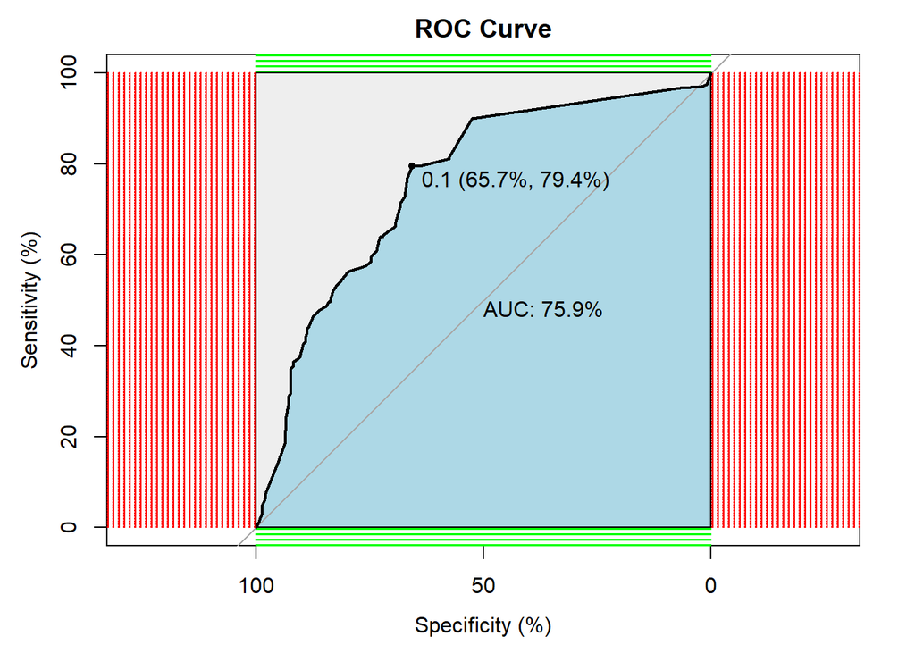

```r
p1 <- predict(best_tree_model, dt_test, type = 'prob')
p1 <- p1[,2]
r <- multiclass.roc(dt_test$Target, p1, percent = TRUE)
roc <- r[['rocs']]
r1 <- roc[[1]]
plot.roc(r1,
         print.auc=TRUE,
         auc.polygon=TRUE,
         grid=c(0.1, 0.2),
         grid.col=c("green", "red"),
         max.auc.polygon=TRUE,
         auc.polygon.col="lightblue",
         print.thres=TRUE,
         main= 'ROC Curve')
```

### Part 2.5 : Random Forest Algorithm

Let’s move with the third one which is the Random Forest (RF) algorithm.

First, arranging the dataset in order not to mutate original one, we copy from it.

```r
# Copying the main dataset
students_data_rf <- data.table(students_data)

head(students_data_rf)
```

```
##    Marital.status Application.mode Application.order Course
## 1:              1               17                 5    171
## 2:              1               15                 1   9254
## 3:              1                1                 5   9070
## 4:              1               17                 2   9773
## 5:              2               39                 1   8014
## 6:              2               39                 1   9991
##    Daytime.evening.attendance. Previous.qualification
## 1:                           1                      1
## 2:                           1                      1
## 3:                           1                      1
## 4:                           1                      1
## 5:                           0                      1
## 6:                           0                     19
##    Previous.qualification..grade. Nacionality Mother.s.qualification
```

[output cut: 90 more lines]

```r
dim(students_data_rf)
```

```
## [1] 4424   37
```

```r
students_data_rf <- na.omit(students_data_rf)
validationIndex <- createDataPartition(students_data_rf$Target, p=0.70, list=FALSE)

rf_train <- students_data_rf[validationIndex,] # 70% of data to training
rf_test <- students_data_rf[-validationIndex,]

cat("Dimension of the main dataset:",dim(students_data_rf))
```

```
## Dimension of the main dataset: 4424 37
```

```r
cat("Dimension of the train dataset:",dim(rf_train))
```

```
## Dimension of the train dataset: 3098 37
```

```r
cat("Dimension of the test dataset:",dim(rf_test))
```

```
## Dimension of the test dataset: 1326 37
```

Dataset is ready to be learned and now we are going to implement a manual cross validation to tune the hyperparameters for the random forest and we are going to look at its error value in each iteration.

Assuming the tuning hyperparameter will be only the effect of the ratio of the number of features evaluated at each split (mtry) and setting other parameters as J=500 and the minimal number of observations per tree leaf=5.

In the end, we are going to store them in table to find the best model.

```r
set.seed(50)
# CV RF

# Set the number of trees and nodesize
num_trees <- 500
min_obs_per_leaf <- 5

# Create a grid of mtry values to explore
mtry_values <- c(2, 4, 6, 8, 10, 15, 20)  # Add more values as needed

# Create an empty data frame to store results
rf_results <- data.frame(mtry = numeric(0), error_rate = numeric(0))

# Perform grid search
for (m in mtry_values) {
  # Train the Random Forest model
  rf_model <- randomForest(Target ~ ., data = rf_train,
                           ntree = num_trees, nodesize = min_obs_per_leaf, mtry = m)

  # Make predictions on the training set
  predictions <- predict(rf_model, dt_train)

  # Calculate the error rate (you may want to use a more appropriate metric)
  error_rate <- mean(predictions != rf_train$Target)

  # Store the results
  rf_results <- rbind(rf_results, data.frame(mtry = m, error_rate = error_rate))
}

# Print the results
print(rf_results)
```

```
##   mtry error_rate
## 1    2  0.5713363
## 2    4  0.5800516
## 3    6  0.5836023
## 4    8  0.5852163
## 5   10  0.5858618
## 6   15  0.5868302
## 7   20  0.5848935
```

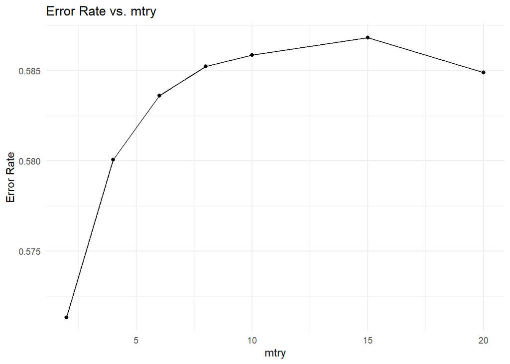

```r
# Create a line plot
ggplot(rf_results, aes(x = mtry, y = error_rate)) +
  geom_line() +
  geom_point() +
  labs(title = "Error Rate vs. mtry",
       x = "mtry",
       y = "Error Rate") +
  theme_minimal()
```

Looks like the model with `mtry` = 2 (given `ntree` = 500 & `nodesize` = 5) is the best model in terms of error rate, lets also analyze confusion matrix.

```r
best_rf_model <- randomForest(Target ~ ., data = rf_train,
                              ntree = num_trees, nodesize = min_obs_per_leaf, mtry = 2)

# Make predictions on the train set
rf_predictions.train <- predict(best_rf_model, newdata = rf_train)

# Create the confusion matrix
rf_confusion_matrix.train <- confusionMatrix(rf_predictions.train, rf_train$Target)

# Print the confusion matrix
print(rf_confusion_matrix.train)
```

```
## Confusion Matrix and Statistics
##
##           Reference
## Prediction Dropout Enrolled Graduate
##   Dropout      925       37       18
##   Enrolled       0      422        0
##   Graduate      70       97     1529
##
## Overall Statistics
##
##                Accuracy : 0.9283
##                  95% CI : (0.9187, 0.9372)
##     No Information Rate : 0.4994
##     P-Value [Acc > NIR] : < 2.2e-16
##
##                   Kappa : 0.8807
##
##  Mcnemar's Test P-Value : < 2.2e-16
##
## Statistics by Class:
##
##                      Class: Dropout Class: Enrolled Class: Graduate
## Sensitivity                  0.9296          0.7590          0.9884
## Specificity                  0.9738          1.0000          0.8923
## Pos Pred Value               0.9439          1.0000          0.9015
## Neg Pred Value               0.9669          0.9499          0.9872
## Prevalence                   0.3212          0.1795          0.4994
## Detection Rate               0.2986          0.1362          0.4935
## Detection Prevalence         0.3163          0.1362          0.5474
## Balanced Accuracy            0.9517          0.8795          0.9403
```

```r
# Make predictions on the test set
rf_predictions.test <- predict(best_rf_model, newdata = rf_test)

# Create the confusion matrix
rf_confusion_matrix.test <- confusionMatrix(rf_predictions.test, rf_test$Target)

# Print the confusion matrix
print(rf_confusion_matrix.test)
```

```
## Confusion Matrix and Statistics
##
##           Reference
## Prediction Dropout Enrolled Graduate
##   Dropout      324       69       30
##   Enrolled      20       47        9
##   Graduate      82      122      623
##
## Overall Statistics
##
##                Accuracy : 0.7496
##                  95% CI : (0.7254, 0.7727)
##     No Information Rate : 0.4992
##     P-Value [Acc > NIR] : < 2.2e-16
##
##                   Kappa : 0.5652
##
##  Mcnemar's Test P-Value : < 2.2e-16
##
## Statistics by Class:
##
##                      Class: Dropout Class: Enrolled Class: Graduate
## Sensitivity                  0.7606         0.19748          0.9411
## Specificity                  0.8900         0.97335          0.6928
## Pos Pred Value               0.7660         0.61842          0.7533
## Neg Pred Value               0.8870         0.84720          0.9218
## Prevalence                   0.3213         0.17949          0.4992
## Detection Rate               0.2443         0.03544          0.4698
## Detection Prevalence         0.3190         0.05732          0.6237
## Balanced Accuracy            0.8253         0.58541          0.8169
```

Its confusion matrices with respect to training & test dataset are above It classifies the target values near 92% with the training dataset. However, it has some difficulties with new dataset as expected.

Finally, let’s look at the variable importance and the partial dependence plots. VarImp plot basically shows which feature has the most contribution to the model while it is improving (making purer). Partial Dependence plot is the plot showing the effect of selected feature to the predictions.

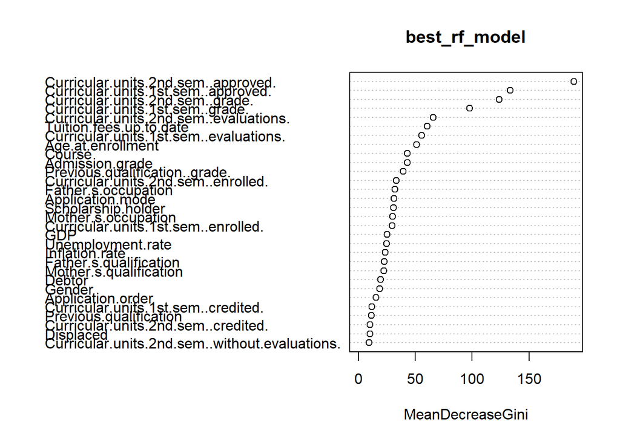

```r
# Plot variable importance
varImpPlot(best_rf_model)
```

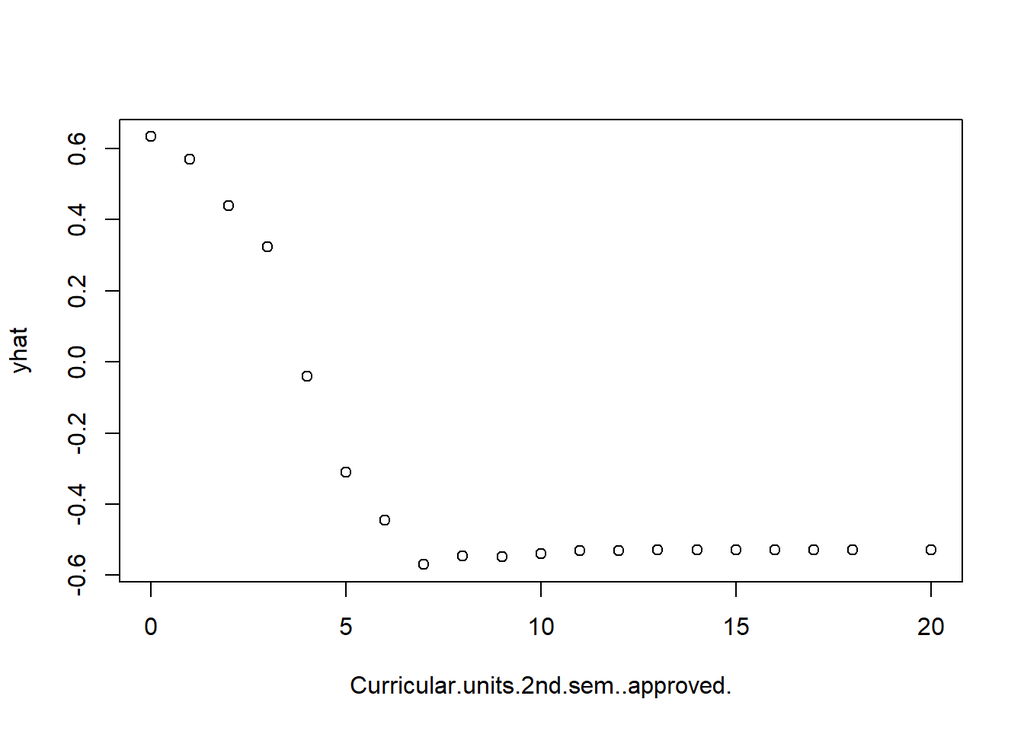

```r
# Create partial dependence plot
partial_plot <- partial(best_rf_model, pred.var = 'Curricular.units.2nd.sem..approved.', data = dt_test)

# Plot the partial dependence plot
plot(partial_plot)
```

### Part 2.6 : GBM Algorithm

First, arranging the dataset in order not to mutate original one, we copy from it.

```r
students_data_gbm <- data.table(students_data)

head(students_data_gbm)
```

```
##    Marital.status Application.mode Application.order Course
## 1:              1               17                 5    171
## 2:              1               15                 1   9254
## 3:              1                1                 5   9070
## 4:              1               17                 2   9773
## 5:              2               39                 1   8014
## 6:              2               39                 1   9991
##    Daytime.evening.attendance. Previous.qualification
## 1:                           1                      1
## 2:                           1                      1
## 3:                           1                      1
## 4:                           1                      1
## 5:                           0                      1
## 6:                           0                     19
##    Previous.qualification..grade. Nacionality Mother.s.qualification
```

[output cut: 90 more lines]

```r
dim(students_data_gbm)
```

```
## [1] 4424   37
```

```r
# Remove rows with any NA values
students_data_gbm <- na.omit(students_data_gbm)
validationIndex <- createDataPartition(students_data_gbm$Target, p=0.70, list=FALSE)

gbm_train <- students_data_gbm[validationIndex,] # 70% of data to training
gbm_test <- students_data_gbm[-validationIndex,]

cat("Dimension of the main dataset:",dim(students_data_gbm))
```

```
## Dimension of the main dataset: 4424 37
```

```r
cat("Dimension of the train dataset:",dim(gbm_train))
```

```
## Dimension of the train dataset: 3098 37
```

```r
cat("Dimension of the test dataset:",dim(gbm_test))
```

```
## Dimension of the test dataset: 1326 37
```

Let’s tune the hyperparameters of the GBM with respect to the “AUC” value.

We are mainly interested in tuning the depth (interaction.depth), the number of trees (n.trees) and the learning rate (shrinkage). Also, I have took a help from the lecture notes in this part.

Since it is a multiclass-classification problem, we are going to use the multiClassSummary as the summaryFunction in trainControl and search as GridSearch.

```r
set.seed(10)


n_folds=10

fitControl=trainControl(method = "cv",
                        number = n_folds,
                        classProbs=TRUE,
                        search = "grid",
                        summaryFunction = multiClassSummary)
## gradient boosting
gbmGrid=expand.grid(interaction.depth = c(3, 5),
                    n.trees = c(1:5)*100,
                    shrinkage = c(0.05,0.1),
                    n.minobsinnode = 10)
set.seed(1)
gbm_fit=train(Target ~ ., data = gbm_train,
              method = "gbm",
              trControl = fitControl, metric='AUC',
              tuneGrid = gbmGrid,
              verbose=F) #verbose is an argument from gbm, prints to screen
gbm_fit
```

```
## Stochastic Gradient Boosting
##
## 3098 samples
##   36 predictor
##    3 classes: 'Dropout', 'Enrolled', 'Graduate'
##
## No pre-processing
## Resampling: Cross-Validated (10 fold)
## Summary of sample sizes: 2790, 2788, 2790, 2788, 2788, 2788, ...
## Resampling results across tuning parameters:
##
##   shrinkage  interaction.depth  n.trees  logLoss    AUC        prAUC
##   0.05       3                  100      0.5775864  0.8835062  0.7430168
##   0.05       3                  200      0.5648780  0.8866040  0.7488102
##   0.05       3                  300      0.5655202  0.8861218  0.7492435
##   0.05       3                  400      0.5673528  0.8864297  0.7509878
##   0.05       3                  500      0.5694716  0.8858688  0.7513989
##   0.05       5                  100      0.5690555  0.8863511  0.7487684
##   0.05       5                  200      0.5611103  0.8891702  0.7545111
##   0.05       5                  300      0.5654029  0.8879899  0.7534066
##   0.05       5                  400      0.5711617  0.8872375  0.7549808
##   0.05       5                  500      0.5797331  0.8859121  0.7513310
##   0.10       3                  100      0.5671953  0.8859244  0.7495736
##   0.10       3                  200      0.5679789  0.8855057  0.7492901
##   0.10       3                  300      0.5775242  0.8840393  0.7471790
##   0.10       3                  400      0.5870020  0.8826513  0.7462452
##   0.10       3                  500      0.6012340  0.8808865  0.7424557
##   0.10       5                  100      0.5695729  0.8863430  0.7510830
##   0.10       5                  200      0.5852404  0.8836590  0.7488961
##   0.10       5                  300      0.6042558  0.8818770  0.7461360
##   0.10       5                  400      0.6240091  0.8803259  0.7439399
##   0.10       5                  500      0.6431500  0.8798208  0.7427541
##   Accuracy   Kappa      Mean_F1    Mean_Sensitivity  Mean_Specificity
##   0.7647030  0.6027190  0.6840777  0.6748989         0.8679171
##   0.7691962  0.6105423  0.6906992  0.6811945         0.8703461
##   0.7692108  0.6120445  0.6947967  0.6853075         0.8712177
##   0.7679132  0.6097543  0.6921647  0.6829176         0.8706432
##   0.7721099  0.6168409  0.6972761  0.6879924         0.8728193
##   0.7701880  0.6119331  0.6897675  0.6804349         0.8708146
##   0.7724273  0.6176057  0.6988554  0.6892177         0.8730049
```

[output cut: 45 more lines]

```
##   0.2570505            0.7755852
##   0.2569440            0.7800949
##   0.2559777            0.7784673
##   0.2573721            0.7832354
##   0.2552243            0.7783999
##   0.2562898            0.7777917
##   0.2559763            0.7797082
##   0.2555451            0.7796895
##   0.2555448            0.7798956
##   0.2559742            0.7811086
##
## Tuning parameter 'n.minobsinnode' was held constant at a value of 10
## AUC was used to select the optimal model using the largest value.
## The final values used for the model were n.trees = 200, interaction.depth =
##  5, shrinkage = 0.05 and n.minobsinnode = 10.
```

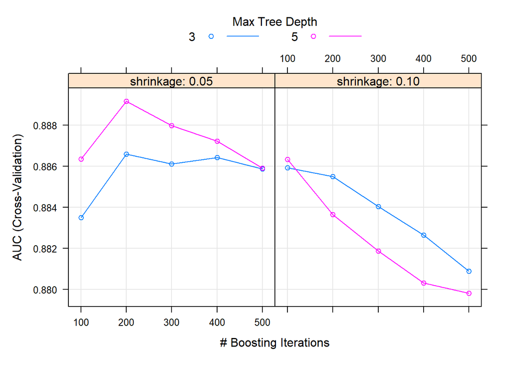

```r
plot(gbm_fit)
```

Selecting the best model is below:

```r
# select the best model
selected_gbm=tolerance(gbm_fit$results, metric = "AUC", tol = 2, maximize = TRUE)
gbm_fit$results[selected_gbm,]
```

```
##   shrinkage interaction.depth n.minobsinnode n.trees   logLoss       AUC
## 1      0.05                 3             10     100 0.5775864 0.8835062
##       prAUC Accuracy    Kappa   Mean_F1 Mean_Sensitivity Mean_Specificity
## 1 0.7430168 0.764703 0.602719 0.6840777        0.6748989        0.8679171
##   Mean_Pos_Pred_Value Mean_Neg_Pred_Value Mean_Precision Mean_Recall
## 1           0.7102507           0.8868856      0.7102507   0.6748989
##   Mean_Detection_Rate Mean_Balanced_Accuracy  logLossSD      AUCSD    prAUCSD
## 1            0.254901               0.771408 0.04396227 0.01925807 0.02698301
##   AccuracySD    KappaSD  Mean_F1SD Mean_SensitivitySD Mean_SpecificitySD
## 1 0.01975885 0.03221791 0.02275552         0.02084063         0.01004853
##   Mean_Pos_Pred_ValueSD Mean_Neg_Pred_ValueSD Mean_PrecisionSD Mean_RecallSD
## 1            0.02840876            0.01197926       0.02840876    0.02084063
##   Mean_Detection_RateSD Mean_Balanced_AccuracySD
## 1           0.006586283               0.01535957
```

Looks like the best GBM model with the parameters (Shrinkage = 0.05, depth = 3, n.trees = 100).

Let’s analyze this model with test data finally.

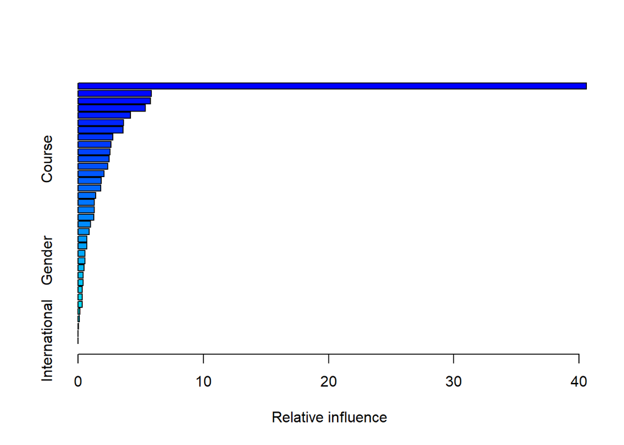

```
##                                                                                           var
## Curricular.units.2nd.sem..approved.                       Curricular.units.2nd.sem..approved.
## Tuition.fees.up.to.date                                               Tuition.fees.up.to.date
## Curricular.units.2nd.sem..grade.                             Curricular.units.2nd.sem..grade.
## Curricular.units.1st.sem..approved.                       Curricular.units.1st.sem..approved.
## Curricular.units.1st.sem..enrolled.                       Curricular.units.1st.sem..enrolled.
## Admission.grade                                                               Admission.grade
## Curricular.units.2nd.sem..evaluations.                 Curricular.units.2nd.sem..evaluations.
## Age.at.enrollment                                                           Age.at.enrollment
## Curricular.units.1st.sem..evaluations.                 Curricular.units.1st.sem..evaluations.
## Curricular.units.1st.sem..grade.                             Curricular.units.1st.sem..grade.
## Course                                                                                 Course
## Previous.qualification..grade.                                 Previous.qualification..grade.
## Mother.s.occupation                                                       Mother.s.occupation
## Curricular.units.2nd.sem..enrolled.                       Curricular.units.2nd.sem..enrolled.
## Father.s.occupation                                                       Father.s.occupation
## Scholarship.holder                                                         Scholarship.holder
## Application.mode                                                             Application.mode
## GDP                                                                                       GDP
## Unemployment.rate                                                           Unemployment.rate
## Father.s.qualification                                                 Father.s.qualification
## Mother.s.qualification                                                 Mother.s.qualification
## Inflation.rate                                                                 Inflation.rate
## Debtor                                                                                 Debtor
## Application.order                                                           Application.order
## Gender                                                                                 Gender
## Curricular.units.2nd.sem..credited.                       Curricular.units.2nd.sem..credited.
## Curricular.units.1st.sem..without.evaluations. Curricular.units.1st.sem..without.evaluations.
## Curricular.units.1st.sem..credited.                       Curricular.units.1st.sem..credited.
## Nacionality                                                                       Nacionality
## Curricular.units.2nd.sem..without.evaluations. Curricular.units.2nd.sem..without.evaluations.
## Displaced                                                                           Displaced
## Previous.qualification                                                 Previous.qualification
## Marital.status                                                                 Marital.status
## Daytime.evening.attendance.                                       Daytime.evening.attendance.
## Educational.special.needs                                           Educational.special.needs
## International                                                                   International
##                                                    rel.inf
## Curricular.units.2nd.sem..approved.            40.58137600
## Tuition.fees.up.to.date                         5.84842546
```

[output cut: 19 more lines]

```
## Inflation.rate                                  0.72084760
## Debtor                                          0.71323281
## Application.order                               0.56911369
## Gender                                          0.55805264
## Curricular.units.2nd.sem..credited.             0.49745836
## Curricular.units.1st.sem..without.evaluations.  0.41807062
## Curricular.units.1st.sem..credited.             0.39474346
## Nacionality                                     0.34376071
## Curricular.units.2nd.sem..without.evaluations.  0.32933585
## Displaced                                       0.32176772
## Previous.qualification                          0.13648089
## Marital.status                                  0.13193469
## Daytime.evening.attendance.                     0.04232902
## Educational.special.needs                       0.00000000
## International                                   0.00000000
```

```r
noftrees=200
depth=5
learning_rate=0.05

boosting_model=gbm(Target~., data=gbm_train,distribution = 'multinomial', n.trees = noftrees,
                   interaction.depth = depth, n.minobsinnode = 10, shrinkage =learning_rate, cv.folds = 10)

summary(boosting_model)
```

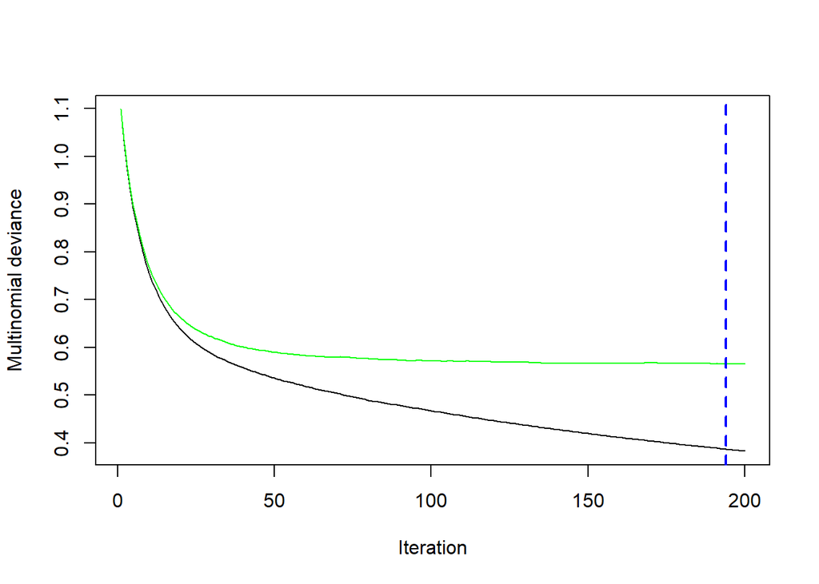

```
## [1] 194
```

```r
gbm.perf(boosting_model, method = "cv")
```

```r
prediction.train <- predict(boosting_model, newdata = gbm_train, type = "response")


predicted_classes <- apply(prediction.train, 1, which.max)


# Create a confusion matrix
conf_matrix <- table(gbm_train$Target, predicted_classes)

# Print the confusion matrix
print(conf_matrix)
```

```
##           predicted_classes
##               1    2    3
##   Dropout   839   53  103
##   Enrolled   51  343  162
##   Graduate   19   32 1496
```

Also analyzing with the test data:

```r
prediction.test <- predict(boosting_model, newdata = gbm_test, type = "response")


predicted_classes <- apply(prediction.test, 1, which.max)


# Create a confusion matrix
conf_matrix <- table(gbm_test$Target, predicted_classes)

# Print the confusion matrix
print(conf_matrix)
```

```
##           predicted_classes
##              1   2   3
##   Dropout  328  41  57
##   Enrolled  61  85  92
##   Graduate  20  36 606
```

```r
# Calculate accuracy
accuracy <- sum(diag(conf_matrix)) / sum(conf_matrix)

# Print the accuracy
print(accuracy)
```

```
## [1] 0.7684766
```

Results are quite good in this sample. Especially, identifying multiple classes is kind of difficult issue to solve and iteratively improving weak learners and obtaining strong learner is the best way to solve this specific problem.

Conclusion : We have worked on a dataset about the diagnosis of the student successes and implemented 4 different learning algorithms with different hyperparameters. We concluded that the Gradient Boosting Machines (GBM) with `(Shrinkage = 0.05, depth = 5, n.trees = 200)` is the algorithm that can explain or classifies the problem most well. Alternatively, randomForest algorithm can be used.

Let’s move on with the third dataset which is about the classification of the malware effectiveness.

## Malware Type Detection Case

### Part 3.0 : Explaining the Malware Case and loading the data.

TUNADROMD dataset contains 4465 instances and 241 attributes. The target attribute for classification is a category (malware vs good ware). (N.B. This is the preprocessed version of TUANDROMD). Purpose is to support malware research and validation of the effectiveness of malware detection methods

This dataset has a large (> 100 features) dimension and it will be costly in any algorithms than the smaller datasets as expected. PCA and MDS can be also used to reduce dimension.

```r
malware_data_path <- paste0(data_path,"Malware/malware.csv")

malware_data <- read.csv(malware_data_path)
```

### Part 3.1 : Data Analysis & Exploring Data & Preprocessing

Since there are many features, there might be some features are ignored to be printed in the report.

```r
dim(malware_data)
```

```
## [1] 4465  242
```

```r
str(malware_data)
```

```
## 'data.frame':    4465 obs. of  242 variables:
##  $ ACCESS_ALL_DOWNLOADS                                             : int  0 0 0 0 0 0 0 0 0 0 ...
##  $ ACCESS_CACHE_FILESYSTEM                                          : int  0 0 0 0 0 0 0 0 0 0 ...
##  $ ACCESS_CHECKIN_PROPERTIES                                        : int  0 0 0 0 0 0 0 0 0 0 ...
##  $ ACCESS_COARSE_LOCATION                                           : int  0 0 0 0 0 0 0 0 0 0 ...
##  $ ACCESS_COARSE_UPDATES                                            : int  0 0 0 0 0 0 0 0 0 0 ...
##  $ ACCESS_FINE_LOCATION                                             : int  0 0 0 0 0 0 0 0 0 0 ...
##  $ ACCESS_LOCATION_EXTRA_COMMANDS                                   : int  0 0 0 0 0 0 0 0 0 0 ...
##  $ ACCESS_MOCK_LOCATION                                             : int  0 0 0 0 0 0 0 0 0 0 ...
##  $ ACCESS_MTK_MMHW                                                  : int  0 0 0 0 0 0 0 0 0 0 ...
##  $ ACCESS_NETWORK_STATE                                             : int  1 1 1 0 0 1 1 1 0 1 ...
##  $ ACCESS_PROVIDER                                                  : int  0 0 0 0 0 0 0 0 0 0 ...
##  $ ACCESS_SERVICE                                                   : int  0 0 0 0 0 0 0 0 0 0 ...
##  $ ACCESS_SHARED_DATA                                               : int  0 0 0 0 0 0 0 0 0 0 ...
##  $ ACCESS_SUPERUSER                                                 : int  0 0 0 0 0 0 0 0 0 0 ...
```

[output cut: 86 more lines]

Analyzing the data whether it has null values. If it has, then we need to handle the missing values.

```r
sum(colSums(sapply(malware_data, is.na)))
```

```
## [1] 242
```

```r
skim(malware_data)
```

Data summary

| Name | malware_data |
| --- | --- |
| Number of rows | 4465 |
| Number of columns | 242 |
| _______________________ |  |
| Column type frequency: |  |
| numeric | 242 |
| ________________________ |  |
| Group variables | None |

**Variable type: numeric**

| skim_variable | n_missing | complete_rate | mean | sd | p0 | p25 | p50 | p75 | p100 | hist |
| --- | --- | --- | --- | --- | --- | --- | --- | --- | --- | --- |
| ACCESS_ALL_DOWNLOADS | 1 | 1 | 0.00 | 0.03 | 0 | 0 | 0 | 0 | 1 | ▇▁▁▁▁ |
| ACCESS_CACHE_FILESYSTEM | 1 | 1 | 0.00 | 0.03 | 0 | 0 | 0 | 0 | 1 | ▇▁▁▁▁ |
| ACCESS_CHECKIN_PROPERTIES | 1 | 1 | 0.00 | 0.07 | 0 | 0 | 0 | 0 | 1 | ▇▁▁▁▁ |
| ACCESS_COARSE_LOCATION | 1 | 1 | 0.08 | 0.28 | 0 | 0 | 0 | 0 | 1 | ▇▁▁▁▁ |
| ACCESS_COARSE_UPDATES | 1 | 1 | 0.01 | 0.08 | 0 | 0 | 0 | 0 | 1 | ▇▁▁▁▁ |
| ACCESS_FINE_LOCATION | 1 | 1 | 0.09 | 0.28 | 0 | 0 | 0 | 0 | 1 | ▇▁▁▁▁ |
| ACCESS_LOCATION_EXTRA_COMMANDS | 1 | 1 | 0.02 | 0.15 | 0 | 0 | 0 | 0 | 1 | ▇▁▁▁▁ |
| ACCESS_MOCK_LOCATION | 1 | 1 | 0.02 | 0.15 | 0 | 0 | 0 | 0 | 1 | ▇▁▁▁▁ |
| ACCESS_MTK_MMHW | 1 | 1 | 0.00 | 0.01 | 0 | 0 | 0 | 0 | 1 | ▇▁▁▁▁ |
| ACCESS_NETWORK_STATE | 1 | 1 | 0.60 | 0.49 | 0 | 0 | 1 | 1 | 1 | ▆▁▁▁▇ |
| ACCESS_PROVIDER | 1 | 1 | 0.00 | 0.00 | 0 | 0 | 0 | 0 | 0 | ▁▁▇▁▁ |
| ACCESS_SERVICE | 1 | 1 | 0.00 | 0.00 | 0 | 0 | 0 | 0 | 0 | ▁▁▇▁▁ |
| ACCESS_SHARED_DATA | 1 | 1 | 0.00 | 0.00 | 0 | 0 | 0 | 0 | 0 | ▁▁▇▁▁ |
| ACCESS_SUPERUSER | 1 | 1 | 0.00 | 0.04 | 0 | 0 | 0 | 0 | 1 | ▇▁▁▁▁ |
| ACCESS_SURFACE_FLINGER | 1 | 1 | 0.00 | 0.07 | 0 | 0 | 0 | 0 | 1 | ▇▁▁▁▁ |
| ACCESS_WIFI_STATE | 1 | 1 | 0.33 | 0.47 | 0 | 0 | 0 | 1 | 1 | ▇▁▁▁▃ |
| activityCalled | 1 | 1 | 0.00 | 0.00 | 0 | 0 | 0 | 0 | 0 | ▁▁▇▁▁ |
| ACTIVITY_RECOGNITION | 1 | 1 | 0.00 | 0.00 | 0 | 0 | 0 | 0 | 0 | ▁▁▇▁▁ |
| ACCOUNT_MANAGER | 1 | 1 | 0.01 | 0.08 | 0 | 0 | 0 | 0 | 1 | ▇▁▁▁▁ |
| ADD_VOICEMAIL | 1 | 1 | 0.02 | 0.14 | 0 | 0 | 0 | 0 | 1 | ▇▁▁▁▁ |
| ANT | 1 | 1 | 0.00 | 0.00 | 0 | 0 | 0 | 0 | 0 | ▁▁▇▁▁ |
| ANT_ADMIN | 1 | 1 | 0.00 | 0.00 | 0 | 0 | 0 | 0 | 0 | ▁▁▇▁▁ |
| AUTHENTICATE_ACCOUNTS | 1 | 1 | 0.03 | 0.18 | 0 | 0 | 0 | 0 | 1 | ▇▁▁▁▁ |
| AUTORUN_MANAGER_LICENSE_MANAGER | 1 | 1 | 0.00 | 0.00 | 0 | 0 | 0 | 0 | 0 | ▁▁▇▁▁ |
| AUTORUN_MANAGER_LICENSE_SERVICE..autorun. | 1 | 1 | 0.00 | 0.00 | 0 | 0 | 0 | 0 | 0 | ▁▁▇▁▁ |
| BATTERY_STATS | 1 | 1 | 0.08 | 0.27 | 0 | 0 | 0 | 0 | 1 | ▇▁▁▁▁ |
| BILLING | 1 | 1 | 0.00 | 0.02 | 0 | 0 | 0 | 0 | 1 | ▇▁▁▁▁ |
| BIND_ACCESSIBILITY_SERVICE | 1 | 1 | 0.01 | 0.08 | 0 | 0 | 0 | 0 | 1 | ▇▁▁▁▁ |
| BIND_APPWIDGET | 1 | 1 | 0.01 | 0.08 | 0 | 0 | 0 | 0 | 1 | ▇▁▁▁▁ |
| BIND_CARRIER_MESSAGING_SERVICE | 1 | 1 | 0.00 | 0.07 | 0 | 0 | 0 | 0 | 1 | ▇▁▁▁▁ |

[output cut: 212 more lines]

Can be seen in the data, there are missing values. First, we need to factorize the target value `Label`. Then, we also need to get rid of the missing values.

```r
malware_data <- na.omit(malware_data)

malware_data$Label <- as.factor(malware_data$Label)
```

We are ready to move on. Let’s make some visualizations to understand data more. It can be seen that There is an imbalance in the class (target) variable between `0` and `1`.

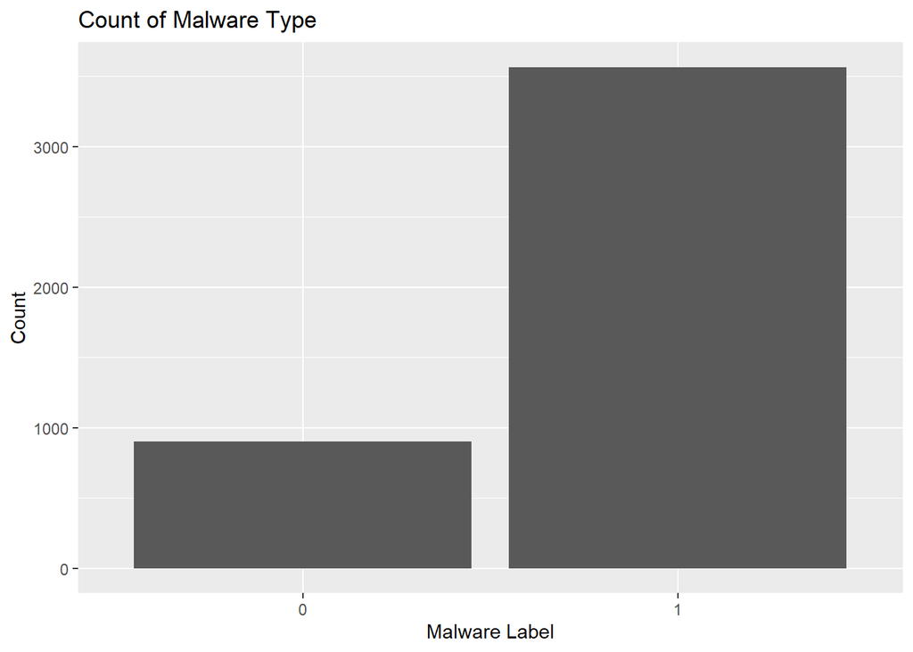

```r
ggplot(malware_data, aes(x = Label )) +
  geom_bar(stat = "count") +
  labs(title = "Count of Malware Type", x = "Malware Label", y = "Count")
```

### Part 3.2 : Train & Test Split for Modeling (Scaled Split)

In order to train the model and then the test its performance, we need to split the data as training and test datasets. Before hand, we also need to scale the features (except the target feature) while using the K-Nearest-Neighbor algorithm since it is highly affected from feature’s scale.

In order not to mutate the main dataset, we’ll copy it and then make the scale and split operation. Also, there are some missing values in some features after scaling, we are going to also remove them from data.

```r
scaled_malware_data <- malware_data
scaled_malware_data[,-242] <- scale(scaled_malware_data[,-242])
validationIndex <- createDataPartition(scaled_malware_data$Label, p=0.70, list=FALSE)

knn_train <- scaled_malware_data[validationIndex,] # 70% of data to training
knn_test <- scaled_malware_data[-validationIndex,]

sum(colSums(sapply(knn_train, is.na)))
```

```
## [1] 131292
```

```r
threshold <- 1000
missing_counts <- colSums(is.na(scaled_malware_data))
columns_to_drop <- names(missing_counts[missing_counts > threshold])
scaled_malware_data <- scaled_malware_data[, !(names(scaled_malware_data) %in% columns_to_drop)]
missing_counts <- colSums(is.na(knn_train))
columns_to_drop <- names(missing_counts[missing_counts > threshold])
knn_train <- knn_train[, !(names(knn_train) %in% columns_to_drop)]
missing_counts <- colSums(is.na(knn_test))
columns_to_drop <- names(missing_counts[missing_counts > threshold])
knn_test <- knn_test[, !(names(knn_test) %in% columns_to_drop)]

sum(colSums(sapply(knn_train, is.na)))
```

```
## [1] 0
```

```r
cat("Dimension of the main dataset:",dim(scaled_malware_data))
```

```
## Dimension of the main dataset: 4464 200
```

```r
cat("Dimension of the train dataset:",dim(knn_train))
```

```
## Dimension of the train dataset: 3126 200
```

```r
cat("Dimension of the test dataset:",dim(knn_test))
```

```
## Dimension of the test dataset: 1338 200
```

Dataset is scaled, has no missing and duplicated values. It is ready to be used in algorithms.

### Part 3.3 : kNN Algorithm (k-Nearest Neighbor)

Let’s start with the kNN algorithm. The algorithm is based on the idea that similar data points tend to be close to each other in the feature space. In other words, the class or value of an unknown data point can be predicted by examining its k-nearest neighbors.

There are two parameters to consider: the distance measure and the number of neighbors. We are mainly interested in two distance measures in this assignment: Euclidean and Manhattan Distance.

Let’s do the Cross Validation to find the optimal k (# of nearest neighbor):

```r
# knn CV
trainControl <- trainControl(method="repeatedcv", number=10, repeats=5)
metric <- "Accuracy"
set.seed(8)

# kNN Part
fit.knn <- train(Label~., data=knn_train, method="knn",
                 metric=metric ,trControl=trainControl)
knn.optimal.k <- fit.knn$bestTune # keep this Initial k for testing with knn() function in next section

print(fit.knn)
```

```
## k-Nearest Neighbors
##
## 3126 samples
##  199 predictor
##    2 classes: '0', '1'
##
## No pre-processing
## Resampling: Cross-Validated (10 fold, repeated 5 times)
## Summary of sample sizes: 2814, 2813, 2813, 2813, 2814, 2814, ...
## Resampling results across tuning parameters:
##
##   k  Accuracy   Kappa
##   5  0.9817668  0.9424832
##   7  0.9781857  0.9310662
##   9  0.9728105  0.9144333
##
## Accuracy was used to select the optimal model using the largest value.
## The final value used for the model was k = 5.
```

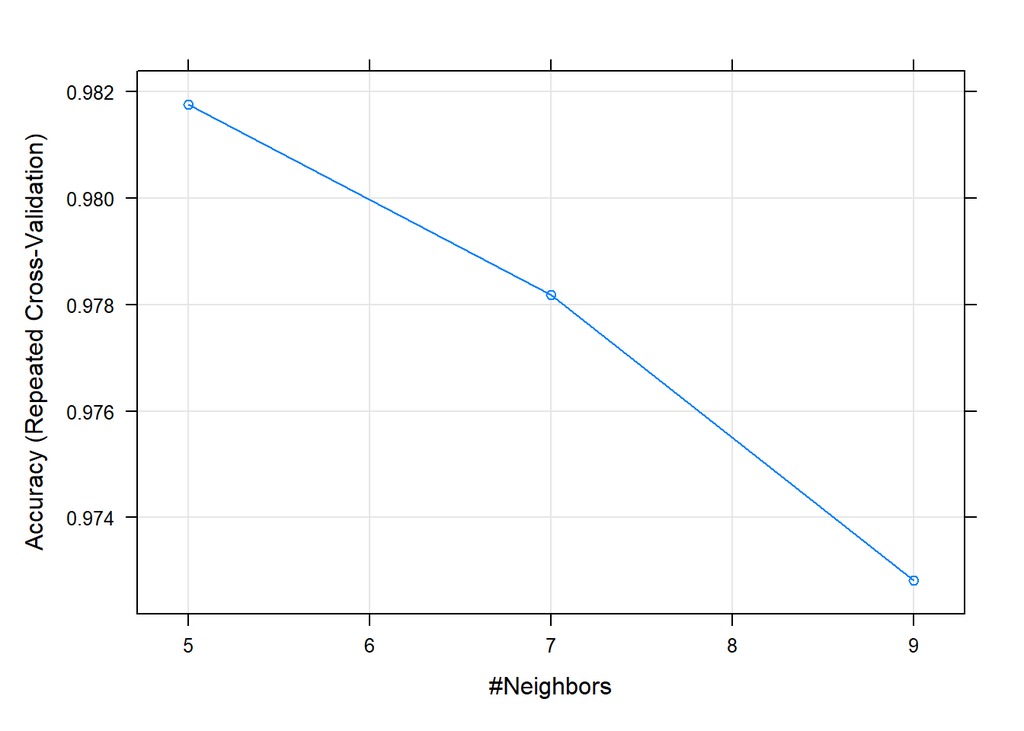

```r
plot(fit.knn)
```

Accuracy was used to select the optimal model using the largest value. After the report of the CV and the plot shows that the final value used for the model was k = 5 and it is the optimum k value for the model.

Confusion matrix for k = 5 is as follows:

```r
prediction <- predict(fit.knn, newdata = knn_test)
cm_knn <- confusionMatrix(prediction, knn_test$Label)
print(cm_knn)
```

```
## Confusion Matrix and Statistics
##
##           Reference
## Prediction    0    1
##          0  255    9
##          1   14 1060
##
##                Accuracy : 0.9828
##                  95% CI : (0.9743, 0.9891)
##     No Information Rate : 0.799
##     P-Value [Acc > NIR] : <2e-16
##
##                   Kappa : 0.9461
##
##  Mcnemar's Test P-Value : 0.4042
##
##             Sensitivity : 0.9480
##             Specificity : 0.9916
##          Pos Pred Value : 0.9659
##          Neg Pred Value : 0.9870
##              Prevalence : 0.2010
##          Detection Rate : 0.1906
##    Detection Prevalence : 0.1973
##       Balanced Accuracy : 0.9698
##
##        'Positive' Class : 0
##
```

Let’s do the analysis for different types of k such as the floor of square root of the dataset size (row)

```r
initial_k <- sqrt(NROW(scaled_malware_data))
initial_k
```

```
## [1] 66.81317
```

```r
knn.floor <- knn(train=knn_train[,-200], test=knn_test[,-200],
                 cl=knn_train$Label, k=floor(initial_k))

# use confusion matrix to calculate accuracy
cm.floor <- confusionMatrix(knn_test$Label,knn.floor)
cm.floor
```

```
## Confusion Matrix and Statistics
##
##           Reference
## Prediction    0    1
##          0  240   29
##          1   28 1041
##
##                Accuracy : 0.9574
##                  95% CI : (0.9452, 0.9676)
##     No Information Rate : 0.7997
##     P-Value [Acc > NIR] : <2e-16
##
##                   Kappa : 0.8672
##
##  Mcnemar's Test P-Value : 1
##
##             Sensitivity : 0.8955
##             Specificity : 0.9729
##          Pos Pred Value : 0.8922
##          Neg Pred Value : 0.9738
##              Prevalence : 0.2003
##          Detection Rate : 0.1794
##    Detection Prevalence : 0.2010
##       Balanced Accuracy : 0.9342
##
##        'Positive' Class : 0
##
```

Finally, lets also look at the model with Manhattan distance using `kknn` library.

```r
knn.manhattan <- train.kknn(Label ~ ., data = knn_train, ks = 5, scale = TRUE, distance = 1)
predictions.manhattan <- predict(knn.manhattan, newdata = knn_test)

cm.manhattan <- table(predictions.manhattan, knn_test$Label)
print(cm.manhattan)
```

```
##
## predictions.manhattan    0    1
##                     0  247    3
##                     1   22 1066
```

```r
accuracy.manhattan <- sum(diag(cm.manhattan)) / sum(cm.manhattan)
print(paste("Accuracy for kNN with Manhattan Distance:", round(accuracy.manhattan,5)))
```

```
## [1] "Accuracy for kNN with Manhattan Distance: 0.98132"
```

Performance of the `Manhattan kNN` is a little worse than the `Euclidean kNN`. Thus, we decided that the best model that explains this dataset is the kNN with `k = 5 & distance = Euclidean`.

### Part 3.4 : Decision Tree Algorithm

Let’s move with the second one which is the Decision Tree (DT) algorithm.

First, arranging the dataset in order not to mutate original one, we copy from it.

```r
# Copying the main dataset
malware_data_dt <- data.table(malware_data)

dim(malware_data_dt)
```

```
## [1] 4464  242
```

```r
# Remove rows with any NA values
malware_data_dt <- na.omit(malware_data_dt)
validationIndex <- createDataPartition(malware_data_dt$Label, p=0.70, list=FALSE)

dt_train <- malware_data_dt[validationIndex,] # 70% of data to training
dt_test <- malware_data_dt[-validationIndex,]

cat("Dimension of the main dataset:",dim(malware_data_dt))
```

```
## Dimension of the main dataset: 4464 242
```

```r
cat("Dimension of the train dataset:",dim(dt_train))
```

```
## Dimension of the train dataset: 3126 242
```

```r
cat("Dimension of the test dataset:",dim(dt_test))
```

```
## Dimension of the test dataset: 1338 242
```

Dataset is ready to be learned and now we are going to implement a manual cross validation to tune the hyperparameters for the decision tree and we are going to look at its Accuracy value in each iteration.

Assuming the tuning hyperparameter will be only the minimal number of observations per tree leaf. Setting complexity parameter to zero and minimum number of observations to split as the twice as the minimal number of observations per tree leaf.

In the end, we are going to store them in df to find the best model.

```r
# Create a data frame to store cross-validation results
cv_results <- data.frame(minbucket = numeric(), accuracy = numeric())

set.seed(10)

# Define a range of minsplit values to try
minbucket_values <- c(1, 5, 10, 15, 20)

# Perform cross-validation for each minbucket value
for (minbucket_val in minbucket_values) {
  # Create a decision tree model with the current minbucket value
  tree_model <- rpart(Label~.,dt_train,method='class',
                      control=rpart.control(cp=0, minbucket = minbucket_val, minsplit = 2*minbucket_val))

  predictions <- predict(tree_model, newdata = dt_train, type = "class")
  correct_predictions <- sum(predictions == dt_train$Label)
  # Calculate accuracy
  accuracy <- round(correct_predictions / nrow(dt_train),5)

  # Store the results in the data frame
  cv_results <- rbind(cv_results, data.frame(minbucket = minbucket_val, accuracy = accuracy))
}

# Print the cross-validation results
print(cv_results)
```

```
##   minbucket accuracy
## 1         1  0.99776
## 2         5  0.98656
## 3        10  0.97921
## 4        15  0.97537
## 5        20  0.97409
```

Best accuracy belongs to the `minbucket` = 1. Thus, the model with `minbucket` = 1 is the best model in terms of Accuracy, lets also analyze its ROC, AUC and confusion matrix.

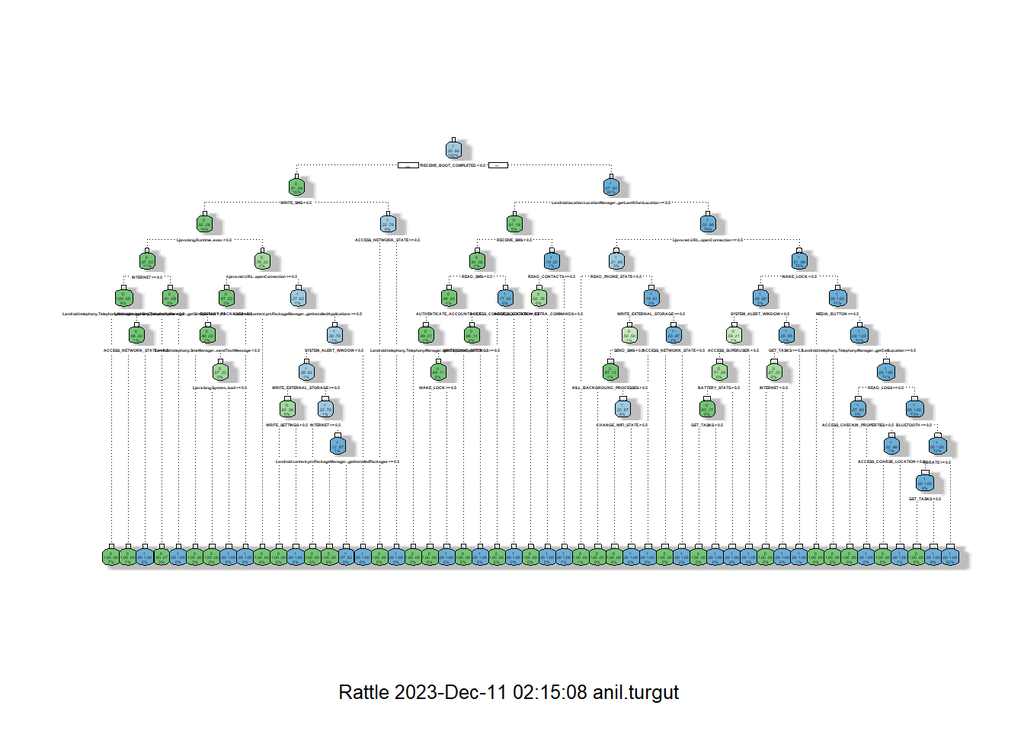

```r
minbucket_val <- 1
best_tree_model <- rpart(Label~.,dt_train,method='class',
                         control=rpart.control(cp=0, minbucket = minbucket_val, minsplit = 2*minbucket_val))

fancyRpartPlot(best_tree_model)
```

Its confusion matrices with respect to training & test dataset are below. It successfully classifies the target values near 99%.

```r
predictions_model <- predict(best_tree_model, newdata = dt_train, type = "class")
cm_train <- confusionMatrix(predictions_model, dt_train$Label)
cm_train
```

```
## Confusion Matrix and Statistics
##
##           Reference
## Prediction    0    1
##          0  629    6
##          1    1 2490
##
##                Accuracy : 0.9978
##                  95% CI : (0.9954, 0.9991)
##     No Information Rate : 0.7985
##     P-Value [Acc > NIR] : <2e-16
##
##                   Kappa : 0.9931
##
##  Mcnemar's Test P-Value : 0.1306
##
##             Sensitivity : 0.9984
##             Specificity : 0.9976
##          Pos Pred Value : 0.9906
##          Neg Pred Value : 0.9996
##              Prevalence : 0.2015
##          Detection Rate : 0.2012
##    Detection Prevalence : 0.2031
##       Balanced Accuracy : 0.9980
##
##        'Positive' Class : 0
##
```

```r
predictions_model.test <- predict(best_tree_model, newdata = dt_test, type = "class")
cm_test <- confusionMatrix(predictions_model.test, dt_test$Label)
cm_test
```

```
## Confusion Matrix and Statistics
##
##           Reference
## Prediction    0    1
##          0  256    4
##          1   13 1065
##
##                Accuracy : 0.9873
##                  95% CI : (0.9797, 0.9926)
##     No Information Rate : 0.799
##     P-Value [Acc > NIR] : < 2e-16
##
##                   Kappa : 0.9599
##
##  Mcnemar's Test P-Value : 0.05235
##
##             Sensitivity : 0.9517
##             Specificity : 0.9963
##          Pos Pred Value : 0.9846
##          Neg Pred Value : 0.9879
##              Prevalence : 0.2010
##          Detection Rate : 0.1913
##    Detection Prevalence : 0.1943
##       Balanced Accuracy : 0.9740
##
##        'Positive' Class : 0
##
```

It is also very successful with the test dataset. Finally, we can look its ROC curve and AUC score

[figure not shown]

```r
p1 <- predict(best_tree_model, dt_test, type = 'prob')
p1 <- p1[,2]
r <- multiclass.roc(dt_test$Label, p1, percent = TRUE)
roc <- r[['rocs']]
r1 <- roc[[1]]
plot.roc(r1,
         print.auc=TRUE,
         auc.polygon=TRUE,
         grid=c(0.1, 0.2),
         grid.col=c("green", "red"),
         max.auc.polygon=TRUE,
         auc.polygon.col="lightblue",
         print.thres=TRUE,
         main= 'ROC Curve')
```

### Part 3.5 : Random Forest Algorithm

Let’s move with the third one which is the Random Forest (RF) algorithm.

First, arranging the dataset in order not to mutate original one, we copy from it.

```r
# Copying the main dataset
malware_data_rf <- data.table(malware_data)

dim(malware_data_rf)
```

```
## [1] 4464  242
```

```r
malware_data_rf <- na.omit(malware_data_rf)
validationIndex <- createDataPartition(malware_data_rf$Label, p=0.70, list=FALSE)

rf_train <- malware_data_rf[validationIndex,] # 70% of data to training
rf_test <- malware_data_rf[-validationIndex,]

cat("Dimension of the main dataset:",dim(malware_data_rf))
```

```
## Dimension of the main dataset: 4464 242
```

```r
cat("Dimension of the train dataset:",dim(rf_train))
```

```
## Dimension of the train dataset: 3126 242
```

```r
cat("Dimension of the test dataset:",dim(rf_test))
```

```
## Dimension of the test dataset: 1338 242
```

Dataset is ready to be learned and now we are going to implement a manual cross validation to tune the hyperparameters for the random forest and we are going to look at its error value in each iteration.

Assuming the tuning hyperparameter will be only the effect of the ratio of the number of features evaluated at each split (mtry) and setting other parameters as J=500 and the minimal number of observations per tree leaf=5.

In the end, we are going to store them in table to find the best model.

```r
set.seed(50)
# CV RF

# Set the number of trees and nodesize
num_trees <- 500
min_obs_per_leaf <- 5

# Create a grid of mtry values to explore
mtry_values <- c(2, 4, 6, 8, 10, 15, 20)  # Add more values as needed

# Create an empty data frame to store results
rf_results <- data.frame(mtry = numeric(0), error_rate = numeric(0))

# Perform grid search
for (m in mtry_values) {
  # Train the Random Forest model
  rf_model <- randomForest(Label ~ ., data = rf_train,
                           ntree = num_trees, nodesize = min_obs_per_leaf, mtry = m)

  # Make predictions on the training set
  predictions <- predict(rf_model, dt_train)

  # Calculate the error rate (you may want to use a more appropriate metric)
  error_rate <- mean(predictions != rf_train$Label)

  # Store the results
  rf_results <- rbind(rf_results, data.frame(mtry = m, error_rate = error_rate))
}

# Print the results
print(rf_results)
```

```
##   mtry error_rate
## 1    2 0.20025592
## 2    4 0.09085093
## 3    6 0.02879079
## 4    8 0.02111324
## 5   10 0.01823417
## 6   15 0.01759437
## 7   20 0.01375560
```

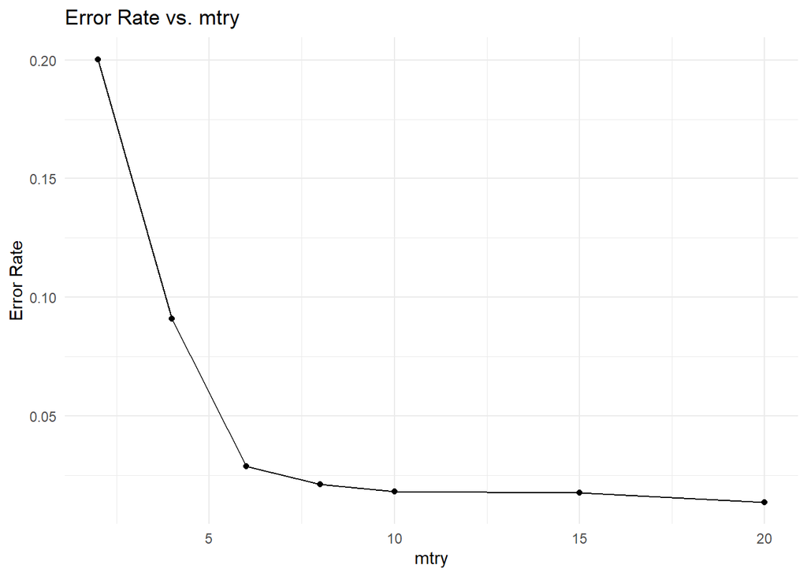

```r
# Create a line plot
ggplot(rf_results, aes(x = mtry, y = error_rate)) +
  geom_line() +
  geom_point() +
  labs(title = "Error Rate vs. mtry",
       x = "mtry",
       y = "Error Rate") +
  theme_minimal()
```

```r
best_rf_model <- randomForest(Label ~ ., data = rf_train,
                              ntree = num_trees, nodesize = min_obs_per_leaf, mtry = 10)

# Make predictions on the train set
rf_predictions.train <- predict(best_rf_model, newdata = rf_train)

# Create the confusion matrix
rf_confusion_matrix.train <- confusionMatrix(rf_predictions.train, rf_train$Label)

# Print the confusion matrix
print(rf_confusion_matrix.train)
```

```
## Confusion Matrix and Statistics
##
##           Reference
## Prediction    0    1
##          0  626   30
##          1    4 2466
##
##                Accuracy : 0.9891
##                  95% CI : (0.9848, 0.9925)
##     No Information Rate : 0.7985
##     P-Value [Acc > NIR] : < 2.2e-16
##
##                   Kappa : 0.9667
##
##  Mcnemar's Test P-Value : 1.807e-05
##
##             Sensitivity : 0.9937
##             Specificity : 0.9880
##          Pos Pred Value : 0.9543
##          Neg Pred Value : 0.9984
##              Prevalence : 0.2015
##          Detection Rate : 0.2003
##    Detection Prevalence : 0.2099
##       Balanced Accuracy : 0.9908
##
##        'Positive' Class : 0
##
```

```r
# Make predictions on the test set
rf_predictions.test <- predict(best_rf_model, newdata = rf_test)

# Create the confusion matrix
rf_confusion_matrix.test <- confusionMatrix(rf_predictions.test, rf_test$Label)

# Print the confusion matrix
print(rf_confusion_matrix.test)
```

```
## Confusion Matrix and Statistics
##
##           Reference
## Prediction    0    1
##          0  260    9
##          1    9 1060
##
##                Accuracy : 0.9865
##                  95% CI : (0.9788, 0.992)
##     No Information Rate : 0.799
##     P-Value [Acc > NIR] : <2e-16
##
##                   Kappa : 0.9581
##
##  Mcnemar's Test P-Value : 1
##
##             Sensitivity : 0.9665
##             Specificity : 0.9916
##          Pos Pred Value : 0.9665
##          Neg Pred Value : 0.9916
##              Prevalence : 0.2010
##          Detection Rate : 0.1943
##    Detection Prevalence : 0.2010
##       Balanced Accuracy : 0.9791
##
##        'Positive' Class : 0
##
```

Its confusion matrices with respect to training & test dataset are above It classifies the target values near 99% wtih the training dataset. Also, it successfully classifies the test dataset.

Finally, let’s look at the variable importance and the partial dependence plots. VarImp plot basically shows which feature has the most contribution to the model while it is improving (making purer). Partial Dependence plot is the plot showing the effect of selected feature to the predictions.

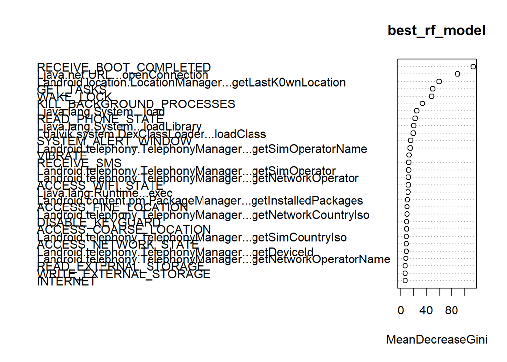

```r
# Plot variable importance
varImpPlot(best_rf_model)
```

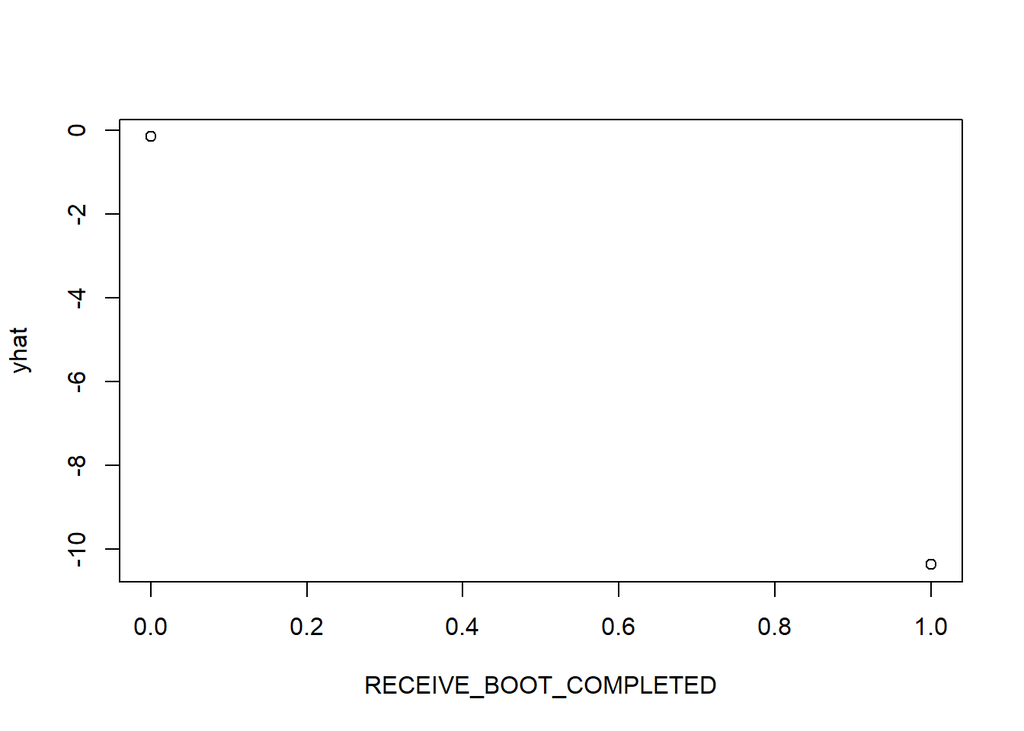

```r
# Create partial dependence plot
partial_plot <- partial(best_rf_model, pred.var = 'RECEIVE_BOOT_COMPLETED', data = dt_test)

# Plot the partial dependence plot
plot(partial_plot)
```

### Part 3.6 : GBM Algorithm

First, arranging the dataset in order not to mutate original one, we copy from it.

```r
malware_data_gbm <- data.table(malware_data)
# Making the target value numeric to use in gbm
malware_data_gbm$Label <- as.numeric(malware_data_gbm$Label)
malware_data_gbm <- transform(malware_data_gbm, Label=Label-1)

dim(malware_data_gbm)
```

```
## [1] 4464  242
```

```r
# Remove rows with any NA values
malware_data_gbm <- na.omit(malware_data_gbm)
validationIndex <- createDataPartition(malware_data_gbm$Label, p=0.70, list=FALSE)

gbm_train <- malware_data_gbm[validationIndex,] # 70% of data to training
gbm_test <- malware_data_gbm[-validationIndex,]

# To use in cross validation I have replace "0" with "no" else "yes"
gbm_train_revised <- gbm_train
gbm_test_revised <- gbm_test

gbm_train_revised$Label <- ifelse(gbm_train_revised$Label == "0", "malware", "goodware")
gbm_train_revised$Label <- as.factor(gbm_train_revised$Label )

gbm_test_revised$Label <- ifelse(gbm_test_revised$Label == "0", "malware", "goodware")
gbm_test_revised$Label <- as.factor(gbm_test_revised$Label )

cat("Dimension of the main dataset:",dim(malware_data_gbm))
```

```
## Dimension of the main dataset: 4464 242
```

```r
cat("Dimension of the train dataset:",dim(gbm_train))
```

```
## Dimension of the train dataset: 3125 242
```

```r
cat("Dimension of the test dataset:",dim(gbm_test))
```

```
## Dimension of the test dataset: 1339 242
```

In above, there are 2 train & test pairs occur. One will be used in the cross validation and the other will be used to test the best model with tuned parameters.

Let’s tune the hyperparameters of the GBM with respect to the “AUC” value”.

We are mainly interested in tuning the depth (interaction.depth), the number of trees (n.trees) and the learning rate (shrinkage). Also, I have took a help from the lecture notes in this part.

```r
set.seed(10)

n_folds=10

fitControl=trainControl(method = "cv",
                        number = n_folds,
                        classProbs=TRUE, summaryFunction=twoClassSummary)
## gradient boosting
gbmGrid=expand.grid(interaction.depth = c(3, 5),
                    n.trees = c(1:5)*100,
                    shrinkage = c(0.05,0.1),
                    n.minobsinnode = 10)
set.seed(1)
gbm_fit=train(Label ~ ., data = gbm_train_revised,
              method = "gbm",
              trControl = fitControl, metric='ROC',
              tuneGrid = gbmGrid,
              verbose=F) #verbose is an argument from gbm, prints to screen
gbm_fit
```

```
## Stochastic Gradient Boosting
##
## 3125 samples
##  241 predictor
##    2 classes: 'goodware', 'malware'
##
## No pre-processing
## Resampling: Cross-Validated (10 fold)
## Summary of sample sizes: 2812, 2813, 2812, 2812, 2812, 2813, ...
## Resampling results across tuning parameters:
##
##   shrinkage  interaction.depth  n.trees  ROC        Sens       Spec
##   0.05       3                  100      0.9957015  0.9851406  0.9448413
##   0.05       3                  200      0.9970519  0.9855422  0.9511161
##   0.05       3                  300      0.9976719  0.9899598  0.9463790
##   0.05       3                  400      0.9983382  0.9927711  0.9542411
##   0.05       3                  500      0.9986299  0.9927711  0.9574157
##   0.05       5                  100      0.9968830  0.9871486  0.9510913
##   0.05       5                  200      0.9980688  0.9927711  0.9495784
##   0.05       5                  300      0.9988456  0.9935743  0.9543155
##   0.05       5                  400      0.9989344  0.9935743  0.9606151
##   0.05       5                  500      0.9989977  0.9951807  0.9653274
##   0.10       3                  100      0.9968120  0.9867470  0.9526786
##   0.10       3                  200      0.9980495  0.9923695  0.9526786
##   0.10       3                  300      0.9986837  0.9927711  0.9605903
##   0.10       3                  400      0.9988831  0.9943775  0.9653026
##   0.10       3                  500      0.9989408  0.9951807  0.9637401
##   0.10       5                  100      0.9979004  0.9931727  0.9511161
##   0.10       5                  200      0.9988992  0.9939759  0.9637401
##   0.10       5                  300      0.9990734  0.9951807  0.9700645
##   0.10       5                  400      0.9992064  0.9947791  0.9748016
##   0.10       5                  500      0.9991967  0.9947791  0.9732143
##
## Tuning parameter 'n.minobsinnode' was held constant at a value of 10
## ROC was used to select the optimal model using the largest value.
## The final values used for the model were n.trees = 400, interaction.depth =
##  5, shrinkage = 0.1 and n.minobsinnode = 10.
```

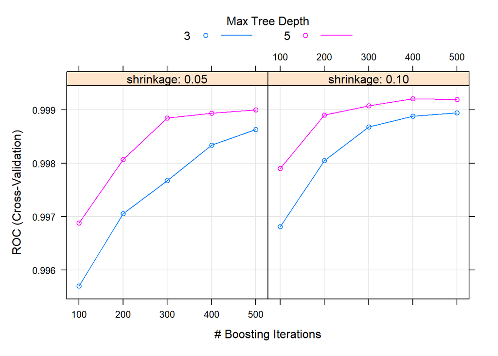

```r
plot(gbm_fit)
```

Selecting the best model is below:

Looks like the best GBM model with the parameters (Shrinkage = 0.1, depth = 5, n.trees = 400).

Let’s analyze this model with test data finally.

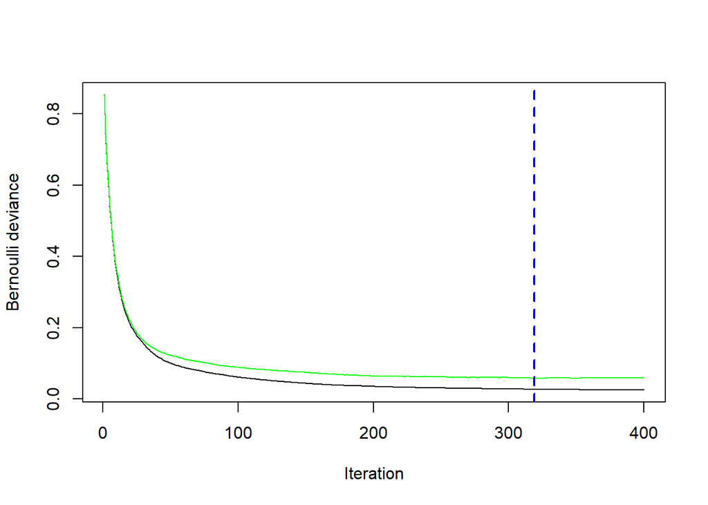

```
## [1] 319
```

```r
noftrees=400
depth=5
learning_rate=0.1

boosting_model=gbm(Label~., data=gbm_train,distribution = 'bernoulli', n.trees = noftrees,
                   interaction.depth = depth, n.minobsinnode = 10, shrinkage =learning_rate, cv.folds = 10)

gbm.perf(boosting_model, method = "cv")
```

```r
prediction.train <- predict(boosting_model, newdata = gbm_train, type = "response")

confusion_data.train <- data.frame(actual = gbm_train$Label,
                                   predicted = ifelse(prediction.train > 0.5,1,0))  # Assuming a threshold of 0.5 for binary classification

# Create a confusion matrix
conf_matrix.train <- confusionMatrix(as.factor(confusion_data.train$predicted), as.factor(confusion_data.train$actual))

print(conf_matrix.train)
```

```
## Confusion Matrix and Statistics
##
##           Reference
## Prediction    0    1
##          0  632    8
##          1    3 2482
##
##                Accuracy : 0.9965
##                  95% CI : (0.9937, 0.9982)
##     No Information Rate : 0.7968
##     P-Value [Acc > NIR] : <2e-16
##
##                   Kappa : 0.9892
##
##  Mcnemar's Test P-Value : 0.2278
##
##             Sensitivity : 0.9953
##             Specificity : 0.9968
##          Pos Pred Value : 0.9875
##          Neg Pred Value : 0.9988
##              Prevalence : 0.2032
##          Detection Rate : 0.2022
##    Detection Prevalence : 0.2048
##       Balanced Accuracy : 0.9960
##
##        'Positive' Class : 0
##
```

Also analyzing with the test data:

```r
prediction.test <- predict(boosting_model, newdata = gbm_test, type = "response")

confusion_data.test <- data.frame(actual = gbm_test$Label,
                                  predicted = ifelse(prediction.test > 0.5,1,0))  # Assuming a threshold of 0.5 for binary classification

# Create a confusion matrix
conf_matrix.test <- confusionMatrix(as.factor(confusion_data.test$predicted), as.factor(confusion_data.test$actual))

print(conf_matrix.test)
```

```
## Confusion Matrix and Statistics
##
##           Reference
## Prediction    0    1
##          0  256    4
##          1    8 1071
##
##                Accuracy : 0.991
##                  95% CI : (0.9844, 0.9954)
##     No Information Rate : 0.8028
##     P-Value [Acc > NIR] : <2e-16
##
##                   Kappa : 0.9715
##
##  Mcnemar's Test P-Value : 0.3865
##
##             Sensitivity : 0.9697
##             Specificity : 0.9963
##          Pos Pred Value : 0.9846
##          Neg Pred Value : 0.9926
##              Prevalence : 0.1972
##          Detection Rate : 0.1912
##    Detection Prevalence : 0.1942
##       Balanced Accuracy : 0.9830
##
##        'Positive' Class : 0
##
```

Conclusion : We have worked on a dataset about is to support malware research and validation of the effectiveness of malware detection methods and we implemented 4 different learning algorithms with different hyperparameters. We concluded that the Gradient Boosting Machines (GBM) with `(Shrinkage = 0.1, depth = 5, n.trees = 400)` is the algorithm that can explain or classifies the problem most well. 4 algorithms are perform extremely good with this dataset in terms of cross-validation errors and test dataset results, however the best one is GBM. But, there is again a tradeoff between cost and performance. This tradeoff must be considered.

Let’s move on with the fourth dataset.

## Glioma Case

### Part 4.0 : Explaining the Glioma Case and loading the data.

Gliomas are the most common primary tumors of the brain. They can be graded as LGG (Lower-Grade Glioma) or GBM (Glioblastoma Multiforme) depending on the histological/imaging criteria. Clinical and molecular/mutation factors are also very crucial for the grading process. Molecular tests are expensive to help accurately diagnose glioma patients.

In this dataset, the most frequently mutated 20 genes and 3 clinical features are considered from TCGA-LGG and TCGA-GBM brain glioma projects.

The prediction task is to determine whether a patient is LGG or GBM with a given clinical and molecular/mutation features. The main objective is to find the optimal subset of mutation genes and clinical features for the glioma grading process to improve performance and reduce costs.

```r
glioma_data_path <- paste0(data_path,"Glioma/glioma.csv")

glioma_data <- read.csv(glioma_data_path)

head(glioma_data)
```

```
##   Grade Gender Age_at_diagnosis Race    IDH1 TP53 ATRX PTEN EGFR CIC MUC16
## 1   LGG      0            51.30    0 MUTATED    0    0    0    0   0     0
## 2   LGG      0            38.72    0 MUTATED    0    0    0    0   1     0
## 3   LGG      0            35.17    0 MUTATED    1    1    0    0   0     0
## 4   LGG      1            32.78    0 MUTATED    1    1    0    0   0     1
## 5   LGG      0            31.51    0 MUTATED    1    1    0    0   0     0
## 6   LGG      1            33.21    0 MUTATED    0    1    0    0   0     0
##   PIK3CA NF1 PIK3R1 FUBP1 RB1 NOTCH1 BCOR CSMD3 SMARCA4 GRIN2A IDH2 FAT4 PDGFRA
## 1      1   0      0     1   0      0    0     0       0      0    0    0      0
## 2      0   0      0     0   0      0    0     0       0      0    0    0      0
## 3      0   0      0     0   0      0    0     0       0      0    0    0      0
## 4      0   0      1     0   0      0    0     0       0      0    0    1      0
## 5      0   0      0     0   0      0    0     0       0      0    0    0      0
## 6      0   0      0     0   0      0    0     0       0      0    0    0      0
```

### Part 4.1 : Data Analysis & Exploring Data & Preprocessing

```r
dim(glioma_data)
```

```
## [1] 839  24
```

```r
str(glioma_data)
```

```
## 'data.frame':    839 obs. of  24 variables:
##  $ Grade           : chr  "LGG" "LGG" "LGG" "LGG" ...
##  $ Gender          : int  0 0 0 1 0 1 1 1 1 0 ...
##  $ Age_at_diagnosis: num  51.3 38.7 35.2 32.8 31.5 ...
##  $ Race            : int  0 0 0 0 0 0 0 0 0 0 ...
##  $ IDH1            : chr  "MUTATED" "MUTATED" "MUTATED" "MUTATED" ...
##  $ TP53            : int  0 0 1 1 1 0 1 1 1 0 ...
##  $ ATRX            : int  0 0 1 1 1 1 0 1 1 0 ...
##  $ PTEN            : int  0 0 0 0 0 0 0 0 0 0 ...
##  $ EGFR            : int  0 0 0 0 0 0 0 0 0 0 ...
##  $ CIC             : int  0 1 0 0 0 0 0 0 0 0 ...
##  $ MUC16           : int  0 0 0 1 0 0 0 0 0 0 ...
##  $ PIK3CA          : int  1 0 0 0 0 0 0 0 0 0 ...
##  $ NF1             : int  0 0 0 0 0 0 0 0 0 0 ...
##  $ PIK3R1          : int  0 0 0 1 0 0 0 0 0 0 ...
##  $ FUBP1           : int  1 0 0 0 0 0 0 0 0 0 ...
##  $ RB1             : int  0 0 0 0 0 0 0 0 0 0 ...
##  $ NOTCH1          : int  0 0 0 0 0 0 0 0 0 0 ...
##  $ BCOR            : int  0 0 0 0 0 0 0 0 0 0 ...
##  $ CSMD3           : int  0 0 0 0 0 0 0 0 0 0 ...
##  $ SMARCA4         : int  0 0 0 0 0 0 0 0 0 0 ...
##  $ GRIN2A          : int  0 0 0 0 0 0 0 0 0 0 ...
##  $ IDH2            : int  0 0 0 0 0 0 0 0 0 0 ...
##  $ FAT4            : int  0 0 0 1 0 0 0 0 0 0 ...
##  $ PDGFRA          : int  0 0 0 0 0 0 0 0 0 0 ...
```

```r
summary(glioma_data)
```

```
##     Grade               Gender       Age_at_diagnosis      Race
##  Length:839         Min.   :0.0000   Min.   :14.42    Min.   :0.0000
##  Class :character   1st Qu.:0.0000   1st Qu.:38.05    1st Qu.:0.0000
##  Mode  :character   Median :0.0000   Median :51.55    Median :0.0000
##                     Mean   :0.4184   Mean   :50.94    Mean   :0.1073
##                     3rd Qu.:1.0000   3rd Qu.:62.80    3rd Qu.:0.0000
##                     Max.   :1.0000   Max.   :89.29    Max.   :3.0000
##      IDH1                TP53             ATRX             PTEN
##  Length:839         Min.   :0.0000   Min.   :0.0000   Min.   :0.0000
##  Class :character   1st Qu.:0.0000   1st Qu.:0.0000   1st Qu.:0.0000
##  Mode  :character   Median :0.0000   Median :0.0000   Median :0.0000
##                     Mean   :0.4148   Mean   :0.2586   Mean   :0.1681
##                     3rd Qu.:1.0000   3rd Qu.:1.0000   3rd Qu.:0.0000
##                     Max.   :1.0000   Max.   :1.0000   Max.   :1.0000
##       EGFR             CIC             MUC16            PIK3CA
##  Min.   :0.0000   Min.   :0.0000   Min.   :0.0000   Min.   :0.00000
##  1st Qu.:0.0000   1st Qu.:0.0000   1st Qu.:0.0000   1st Qu.:0.00000
##  Median :0.0000   Median :0.0000   Median :0.0000   Median :0.00000
##  Mean   :0.1335   Mean   :0.1323   Mean   :0.1168   Mean   :0.08701
##  3rd Qu.:0.0000   3rd Qu.:0.0000   3rd Qu.:0.0000   3rd Qu.:0.00000
##  Max.   :1.0000   Max.   :1.0000   Max.   :1.0000   Max.   :1.00000
##       NF1              PIK3R1            FUBP1              RB1
##  Min.   :0.00000   Min.   :0.00000   Min.   :0.00000   Min.   :0.00000
##  1st Qu.:0.00000   1st Qu.:0.00000   1st Qu.:0.00000   1st Qu.:0.00000
##  Median :0.00000   Median :0.00000   Median :0.00000   Median :0.00000
##  Mean   :0.07986   Mean   :0.06436   Mean   :0.05364   Mean   :0.04768
##  3rd Qu.:0.00000   3rd Qu.:0.00000   3rd Qu.:0.00000   3rd Qu.:0.00000
##  Max.   :1.00000   Max.   :1.00000   Max.   :1.00000   Max.   :1.00000
##      NOTCH1             BCOR             CSMD3            SMARCA4
##  Min.   :0.00000   Min.   :0.00000   Min.   :0.00000   Min.   :0.00000
##  1st Qu.:0.00000   1st Qu.:0.00000   1st Qu.:0.00000   1st Qu.:0.00000
##  Median :0.00000   Median :0.00000   Median :0.00000   Median :0.00000
##  Mean   :0.04529   Mean   :0.03456   Mean   :0.03218   Mean   :0.03218
##  3rd Qu.:0.00000   3rd Qu.:0.00000   3rd Qu.:0.00000   3rd Qu.:0.00000
##  Max.   :1.00000   Max.   :1.00000   Max.   :1.00000   Max.   :1.00000
##      GRIN2A             IDH2              FAT4             PDGFRA
##  Min.   :0.00000   Min.   :0.00000   Min.   :0.00000   Min.   :0.00000
##  1st Qu.:0.00000   1st Qu.:0.00000   1st Qu.:0.00000   1st Qu.:0.00000
##  Median :0.00000   Median :0.00000   Median :0.00000   Median :0.00000
##  Mean   :0.03218   Mean   :0.02741   Mean   :0.02741   Mean   :0.02622
##  3rd Qu.:0.00000   3rd Qu.:0.00000   3rd Qu.:0.00000   3rd Qu.:0.00000
##  Max.   :1.00000   Max.   :1.00000   Max.   :1.00000   Max.   :1.00000
```

Analyzing the data whether it has null values. If it has, then we need to handle the missing values.

```r
colSums(sapply(glioma_data, is.na))
```

```
##            Grade           Gender Age_at_diagnosis             Race
##                0                0                0                0
##             IDH1             TP53             ATRX             PTEN
##                0                0                0                0
##             EGFR              CIC            MUC16           PIK3CA
##                0                0                0                0
##              NF1           PIK3R1            FUBP1              RB1
##                0                0                0                0
##           NOTCH1             BCOR            CSMD3          SMARCA4
##                0                0                0                0
##           GRIN2A             IDH2             FAT4           PDGFRA
##                0                0                0                0
```